# Lab assignment: predicting car prices

[figure not shown]

In this assignment we will attempt to predict how car prices vary (usually going down) from first hand to second hand, according to different vehicle characteristics. We will exploit ensemble techniques to try to obtain as good models as possible.

## Guidelines

Throughout this notebook you will find empty cells that you will need to fill with your own code. Follow the instructions in the notebook and pay special attention to the following symbols.

|  | You will need to solve a question by writing your own code or answer in the cell immediately below, or in a different file as instructed. Both correctness of the solution and code quality will be take… |
| --- | --- |
|  | This is a hint or useful observation that can help you solve this assignment. You are not expected to write any solution, but you should pay attention to them to understand the assignment. |
|  | This is an advanced and voluntary excercise that can help you gain a deeper knowledge into the topic. This exercise won't be taken into account towards marking, but you are encouraged to undertake it.… |

The following code imports the core libraries and objects used. Feel free to import other stuff if you need to in subsequent cells:

```python
# Numpy and random seed
import numpy as np
RANDOM_STATE = 42; np.random.seed(RANDOM_STATE)
# Pandas with Holoviews
import holoviews as hv; hv.extension('bokeh')
import pandas as pd
pd.options.plotting.backend = 'hvplot'
# Inline Matlab plotting
import matplotlib.pyplot as plt
%matplotlib inline
# Sklearn base classifiers
from sklearn.model_selection import train_test_split
from sklearn.linear_model import LinearRegression
from sklearn.tree import DecisionTreeRegressor, plot_tree
```

```python
import warnings
warnings.filterwarnings('ignore')
```

Lastly, if you need any help on the usage of a Python function you can place the writing cursor over its name and press Caps+Shift to produce a pop-out with related documentation. This will only work inside code cells.

Let's go!

## Data loading and preprocessing

In this assignment we will work with the `vehicles` dataset, which was retrieved from Craigslist:

```python
df = pd.read_csv('./data/vehicles/vehicles.csv')
df
```

|  | price | year | manufacturer | condition | cylinders | fuel | odometer | title_status | transmission | drive | type | paint_color |
| --- | --- | --- | --- | --- | --- | --- | --- | --- | --- | --- | --- | --- |
| 0 | 6995 | 2000.0 | gmc | excellent | 8 cylinders | gas | 167783.0 | clean | automatic | 4wd | NaN | red |
| 1 | 8750 | 2013.0 | hyundai | excellent | 4 cylinders | gas | 90821.0 | clean | automatic | fwd | NaN | grey |
| 2 | 10900 | 2013.0 | toyota | good | 4 cylinders | hybrid | 92800.0 | clean | automatic | fwd | NaN | blue |
| 3 | 12500 | 2003.0 | mitsubishi | good | 4 cylinders | gas | NaN | clean | manual | 4wd | sedan | grey |
| 4 | 16995 | 2007.0 | gmc | good | 8 cylinders | diesel | 254217.0 | clean | automatic | 4wd | truck | white |
| ... | ... | ... | ... | ... | ... | ... | ... | ... | ... | ... | ... | ... |
| 423852 | 1600 | 2006.0 | hyundai | fair | 6 cylinders | gas | 159980.0 | clean | automatic | fwd | sedan | blue |
| 423853 | 9000 | 2003.0 | toyota | excellent | 8 cylinders | gas | 160000.0 | clean | automatic | 4wd | SUV | green |
| 423854 | 700 | 1994.0 | ford | fair | 6 cylinders | gas | 212000.0 | clean | manual | rwd | NaN | green |
| 423855 | 3800 | 1999.0 | lincoln | excellent | 8 cylinders | gas | 160000.0 | clean | automatic | rwd | sedan | NaN |
| 423856 | 8650 | 2015.0 | nissan | NaN | NaN | gas | 160526.0 | clean | automatic | fwd | sedan | silver |

423857 rows × 12 columns

Let's take a look at the columns and their meaning:

- `price`: the price (in dollars) the car is trying to be sold at.
- `year`: year when that car was originally bought.
- `manufacturer`: the car brand (Audi, BMW...).
- `condition`: car status (like new, in good/bad condition...).
- `cylinders`: how many cylinders the engine has.
- `fuel`: what kind of fuel it uses.
- `odometer`: mileage it has when sold.
- `title_status`: if it's original or has been modified with extra pieces.
- `transmission`: type of transmission (manual, automatic...).
- `drive`: kind of drive (forward, rear...).
- `type`: category of car (compact, SUV, coupe...).
- `paint_color`: main color of the car (white, red...).

We've a faily large dataset (more than 400K rows), but there're quite a lot of missing values! The only column that is always there is `price`:

```python
df.isna().sum(axis=0)
```

```
price                0
year             95114
manufacturer    110615
condition       247138
cylinders       226178
fuel             96643
odometer        153272
title_status     96098
transmission     95792
drive           192738
type            182700
paint_color     201654
dtype: int64
```

To simplify things, let's simply eliminate all rows that have missing information. This leaves us with barely 86K samples:

```python
df = df.dropna(how='any')
df
```

|  | price | year | manufacturer | condition | cylinders | fuel | odometer | title_status | transmission | drive | type | paint_color |
| --- | --- | --- | --- | --- | --- | --- | --- | --- | --- | --- | --- | --- |
| 4 | 16995 | 2007.0 | gmc | good | 8 cylinders | diesel | 254217.0 | clean | automatic | 4wd | truck | white |
| 5 | 13995 | 2012.0 | ford | good | 6 cylinders | gas | 188406.0 | clean | automatic | 4wd | truck | grey |
| 6 | 7995 | 2010.0 | chevrolet | good | 4 cylinders | gas | 108124.0 | clean | automatic | 4wd | SUV | grey |
| 7 | 8995 | 2011.0 | chevrolet | good | 6 cylinders | gas | 178054.0 | clean | automatic | 4wd | SUV | white |
| 8 | 10995 | 2014.0 | ford | good | 6 cylinders | gas | 170259.0 | clean | automatic | 4wd | SUV | white |
| ... | ... | ... | ... | ... | ... | ... | ... | ... | ... | ... | ... | ... |
| 423849 | 9885 | 2012.0 | subaru | excellent | 4 cylinders | gas | 82000.0 | clean | automatic | 4wd | hatchback | silver |
| 423850 | 750 | 2002.0 | saturn | salvage | 4 cylinders | gas | 40000.0 | missing | manual | fwd | coupe | blue |
| 423851 | 4800 | 2002.0 | ford | good | 6 cylinders | gas | 58000.0 | clean | automatic | rwd | coupe | blue |
| 423852 | 1600 | 2006.0 | hyundai | fair | 6 cylinders | gas | 159980.0 | clean | automatic | fwd | sedan | blue |
| 423853 | 9000 | 2003.0 | toyota | excellent | 8 cylinders | gas | 160000.0 | clean | automatic | 4wd | SUV | green |

85998 rows × 12 columns

Now we should also change `year` and `odometer` to integer type. As for `cylinders`, it can have the value `'other'`, but we can remove the word `'cylinders'` itself:

```python
df = df.astype({'price': 'int32', 'year': 'int16', 'odometer': 'int32'})
df['cylinders'] = df['cylinders'].where(df['cylinders'] == 'other', df['cylinders'].str.replace('cylinders', ''))
df
```

|  | price | year | manufacturer | condition | cylinders | fuel | odometer | title_status | transmission | drive | type | paint_color |
| --- | --- | --- | --- | --- | --- | --- | --- | --- | --- | --- | --- | --- |
| 4 | 16995 | 2007 | gmc | good | 8 | diesel | 254217 | clean | automatic | 4wd | truck | white |
| 5 | 13995 | 2012 | ford | good | 6 | gas | 188406 | clean | automatic | 4wd | truck | grey |
| 6 | 7995 | 2010 | chevrolet | good | 4 | gas | 108124 | clean | automatic | 4wd | SUV | grey |
| 7 | 8995 | 2011 | chevrolet | good | 6 | gas | 178054 | clean | automatic | 4wd | SUV | white |
| 8 | 10995 | 2014 | ford | good | 6 | gas | 170259 | clean | automatic | 4wd | SUV | white |
| ... | ... | ... | ... | ... | ... | ... | ... | ... | ... | ... | ... | ... |
| 423849 | 9885 | 2012 | subaru | excellent | 4 | gas | 82000 | clean | automatic | 4wd | hatchback | silver |
| 423850 | 750 | 2002 | saturn | salvage | 4 | gas | 40000 | missing | manual | fwd | coupe | blue |
| 423851 | 4800 | 2002 | ford | good | 6 | gas | 58000 | clean | automatic | rwd | coupe | blue |
| 423852 | 1600 | 2006 | hyundai | fair | 6 | gas | 159980 | clean | automatic | fwd | sedan | blue |
| 423853 | 9000 | 2003 | toyota | excellent | 8 | gas | 160000 | clean | automatic | 4wd | SUV | green |

85998 rows × 12 columns

As for the numerical columns, note that there are some extreme values:

```python
df.describe(percentiles=[0.01, 0.05, 0.10, 0.25, 0.50, 0.75, 0.90, 0.95, 0.99])
```

|  | price | year | odometer |
| --- | --- | --- | --- |
| count | 8.599800e+04 | 85998.000000 | 8.599800e+04 |
| mean | -7.240961e+03 | 2009.090107 | 1.137648e+05 |
| std | 6.167590e+06 | 8.666905 | 1.241751e+05 |
| min | -1.804436e+09 | 1923.000000 | 0.000000e+00 |
| 1% | 0.000000e+00 | 1971.000000 | 1.100000e+02 |
| 5% | 6.000000e+02 | 1996.000000 | 1.307700e+04 |
| 10% | 2.495000e+03 | 2001.000000 | 2.800000e+04 |
| 25% | 4.995000e+03 | 2006.000000 | 6.449175e+04 |
| 50% | 8.995000e+03 | 2011.000000 | 1.079605e+05 |
| 75% | 1.600000e+04 | 2015.000000 | 1.512170e+05 |
| 90% | 2.687300e+04 | 2017.000000 | 1.916000e+05 |
| 95% | 3.475000e+04 | 2018.000000 | 2.189906e+05 |
| 99% | 4.950000e+04 | 2019.000000 | 2.890031e+05 |
| max | 1.234568e+08 | 2021.000000 | 1.000000e+07 |

So let's do the following:

[figure not shown]

Filter out those car samples for which:

- `price` is less than 500 or more than 50000 dollars.
- `year` is less than 1990 or more than 2020.
- `odometer` is exactly 0 or more than 300000 miles.

```python
# Modificamos el DataFrame original después de llamar al método query() estableciendo inplace=True

df.query('price >= 500 and price <= 50000', inplace = True)

df.query('year >= 1990 and year <= 2020', inplace = True)

df.query('odometer > 0 and odometer <= 300000', inplace = True)
```

Restablecemos el íncide de df, pero utilizando 'drop' para evitar que el índice anterior se agregue como una columna:

```python
df.reset_index (drop = True, inplace = True)
df
```

|  | price | year | manufacturer | condition | cylinders | fuel | odometer | title_status | transmission | drive | type | paint_color |
| --- | --- | --- | --- | --- | --- | --- | --- | --- | --- | --- | --- | --- |
| 0 | 16995 | 2007 | gmc | good | 8 | diesel | 254217 | clean | automatic | 4wd | truck | white |
| 1 | 13995 | 2012 | ford | good | 6 | gas | 188406 | clean | automatic | 4wd | truck | grey |
| 2 | 7995 | 2010 | chevrolet | good | 4 | gas | 108124 | clean | automatic | 4wd | SUV | grey |
| 3 | 8995 | 2011 | chevrolet | good | 6 | gas | 178054 | clean | automatic | 4wd | SUV | white |
| 4 | 10995 | 2014 | ford | good | 6 | gas | 170259 | clean | automatic | 4wd | SUV | white |
| ... | ... | ... | ... | ... | ... | ... | ... | ... | ... | ... | ... | ... |
| 77875 | 9885 | 2012 | subaru | excellent | 4 | gas | 82000 | clean | automatic | 4wd | hatchback | silver |
| 77876 | 750 | 2002 | saturn | salvage | 4 | gas | 40000 | missing | manual | fwd | coupe | blue |
| 77877 | 4800 | 2002 | ford | good | 6 | gas | 58000 | clean | automatic | rwd | coupe | blue |
| 77878 | 1600 | 2006 | hyundai | fair | 6 | gas | 159980 | clean | automatic | fwd | sedan | blue |
| 77879 | 9000 | 2003 | toyota | excellent | 8 | gas | 160000 | clean | automatic | 4wd | SUV | green |

77880 rows × 12 columns

Está correcto??

```python
df.describe()
```

|  | price | year | odometer |
| --- | --- | --- | --- |
| count | 77880.000000 | 77880.000000 | 77880.000000 |
| mean | 12425.825411 | 2009.955907 | 112367.978698 |
| std | 9562.850397 | 5.790562 | 60041.652726 |
| min | 500.000000 | 1990.000000 | 1.000000 |
| 25% | 5500.000000 | 2006.000000 | 68562.500000 |
| 50% | 9500.000000 | 2011.000000 | 110787.500000 |
| 75% | 16500.000000 | 2014.000000 | 153000.000000 |
| max | 50000.000000 | 2020.000000 | 300000.000000 |

Now we obtain reasonable distributions on price and year, except that there aren't many cars for very recent years (which makes sense, as those are mostly second hand cars, and in order to be second hand some years must pass!):

##### * Vemos la información graficando los datos y comprobamos si presentan valores razonables:

```python
(
    df['price'].plot(kind='hist', color="#819FF7" , bins=50, bin_range=(0, 50000)).opts(title="Coches según Precio") +
    df['year'].plot(kind='hist', color= "#819FF7", bins=30, bin_range=(1990, 2020)).opts(title="Coches según Año") +
    df['odometer'].plot(kind='hist', color= "#819FF7", bins=30, bin_range=(0, 300000)).opts(
        title='Coches según Cuentakilómetro', xrotation=45)
).cols(1)
```

[interactive chart not shown]

- Con respecto a los precios: Mayor cantidad de coches a un precio medio/bajo como opción para la mayoría de la población y menor número de coches a un precio más elevado. Tiene sentido, puesto que precios de 40.000 dólares no es lo habitual en el mercado de sengunda mano.
- Con respecto de la antigüedad: En 2010 y 2019 se producen fuertes caidas. La primera puede venir arrastrada por la crisis del 2008 y la segunda puede explicarse por la pandemia de la Covid-19.
- Con respecto al kilometraje: La mayor concentración de coches está entorno a las 95000-125000 millas, un valor razonable para coches de segunda mano. El número de coches desciende a medida que se incrementa el kilometraje.

|  | Verify that the rest of features (all categorical) have reasonable values, and check which categories are allowed for each of those features. |
| --- | --- |

```python
# Comprobación de la distribución de datos categóricos

print(df.manufacturer.value_counts())
print(df.condition.value_counts())
print(df.cylinders.value_counts())
print(df.fuel.value_counts())
print(df.title_status .value_counts())
print(df.transmission .value_counts())
print(df.drive .value_counts())
```

```
ford               14296
chevrolet          11298
toyota              6745
honda               5103
nissan              4502
jeep                3465
dodge               3032
gmc                 2897
ram                 2385
subaru              2243
hyundai             2141
bmw                 2106
volkswagen          1900
chrysler            1641
kia                 1626
mercedes-benz       1479
cadillac            1219
lexus               1140
mazda               1082
buick               1037
audi                 819
acura                798
pontiac              708
lincoln              653
volvo                598
infiniti             595
mitsubishi           485
mini                 402
saturn               391
mercury              387
rover                310
jaguar               186
fiat                 163
tesla                 18
harley-davidson       10
alfa-romeo             9
land rover             7
aston-martin           3
porche                 1
Name: manufacturer, dtype: int64
```

[output cut: 22 more lines]

```
clean         73361
rebuilt        2422
salvage        1032
lien            986
missing          57
parts only       22
Name: title_status, dtype: int64
automatic    70273
manual        5436
other         2171
Name: transmission, dtype: int64
fwd    31630
4wd    31228
rwd    15022
Name: drive, dtype: int64
```

Veamos si el resto de características tienen valores razonables, y comprobemos qué categorías admiten cada una de esas características.

```python
pd.value_counts(df['condition'])
```

```
excellent    37420
good         28762
like new      8570
fair          2645
new            291
salvage        192
Name: condition, dtype: int64
```

```python
df['condition'].value_counts().plot.bar(figsize =(10, 7),color = "#819FF7",
                                        title = 'Estado del coche vs Número de coches',
                                        xlabel = 'Estado del coche',
                                        ylabel = 'Número de coches')
```

[interactive chart not shown]

Valores razonables para los distintos estados de conservación.

```python
ax=df.groupby(['drive', 'condition']).price.count().unstack().plot(kind = 'bar', figsize =(10, 7),
                                        title = 'Número de coches por tracción, según condición', rot=45,
                                        xlabel = 'Estado del coche',
                                        ylabel = 'Número de coches')
ax
```

[interactive chart not shown]

```python
pd.value_counts(df['cylinders'])
```

```
6        28638
4        28287
8        19443
5          767
10         388
other      181
3          144
12          32
Name: cylinders, dtype: int64
```

```python
df['cylinders'].value_counts().plot.bar(figsize =(10, 7),color = "#819FF7",
                                        title = 'Cilindros vs Número de coches',
                                        xlabel = 'Cilindros',
                                        ylabel = 'Número de coches')
```

[interactive chart not shown]

Valores razonables para el número de coches dada su cilindrada. Lo habitual son coches de 4, 6 y 8 cilindros. Los motores más modernos pueden tener hasta 16 (coches de carreras) y 12 son los que llevaría por ejemplo un camión o un superdeportivo(que vemos que son los menos en el mercado de 2ª manor) En la categoría "otros" podría estar agrupando otras combinaciones : monocilindros y 7 cilindros.

```python
pd.value_counts(df['fuel'])
```

```
gas         71991
diesel       4018
hybrid       1076
other         687
electric      108
Name: fuel, dtype: int64
```

```python
df['fuel'].value_counts().plot.bar(figsize =(10, 7),color = "#819FF7",
                                        title = 'Combustible vs Número de coches',
                                        xlabel = 'Combustible',
                                        ylabel = 'Número de coches')
```

[interactive chart not shown]

Por lo que he leído, en EEUU lo más habitual es que los coches sean de gasolina, por lo que es coherente que sea la opción más ofertada.

```python
pd.value_counts(df['title_status'])
```

```
clean         73361
rebuilt        2422
salvage        1032
lien            986
missing          57
parts only       22
Name: title_status, dtype: int64
```

```python
df['title_status'].value_counts().plot.bar(figsize =(10, 7),color = "#819FF7",
                                        title = 'Estado del coche vs Número de coches',
                                        xlabel = 'Estado del coche',
                                        ylabel = 'Número de coches')
```

[interactive chart not shown]

Valores razonables.

```python
pd.value_counts(df['transmission'])
```

```
automatic    70273
manual        5436
other         2171
Name: transmission, dtype: int64
```

```python
df['transmission'].value_counts().plot.bar(figsize =(10, 7),color = "#819FF7",
                                        title = 'Tipo de cambio vs Número de coches',
                                        xlabel = 'Tipo de cambio',
                                        ylabel = 'Número de coches')
```

[interactive chart not shown]

En EEUU lo más habitual es que los coches tengan cambio automático.

En la opción "otros" puede estar teniendo en cuenta el cambio robotizado, el ambio de doble embrague o el cambio automático de variador continuo (CVT). Estas opciones son las menos comunes.

```python
pd.value_counts(df['drive'])
```

```
fwd    31630
4wd    31228
rwd    15022
Name: drive, dtype: int64
```

```python
df['drive'].value_counts().plot.bar(figsize =(10, 7),color = "#819FF7",
                                        title = 'Tracción vs Número de coches',
                                        xlabel = 'Tracción',
                                        ylabel = 'Número de coches')
```

[interactive chart not shown]

La tracción delantera (fwd) es la más común. Vemos que está a la par de la tracción 4wd, propia de suv y todoterrenos.

En EEUU hay un número considerable de pick ups que llevan tracción rwd. Esta tracción también es propia de los deportivos. (De ahí que no haya tanto número en el mercado de segunda mano)

```python
pd.value_counts(df['type'])
```

```
sedan          22461
SUV            20698
truck           9389
pickup          6309
coupe           4382
hatchback       3421
van             2962
wagon           2542
mini-van        2490
convertible     1989
other            918
offroad          233
bus               86
Name: type, dtype: int64
```

```python
df['type'].value_counts().plot.bar(figsize =(10, 7),color = "#819FF7",
                                        title = 'Tipo de coche vs Número de coches',
                                        xlabel = 'Tipo de coche',
                                        ylabel = 'Número de coches')
```

[interactive chart not shown]

Valores normales, atendiendo que el mayor número de coches se concentran en turismos y suv.

```python
pd.value_counts(df['paint_color'])
```

```
white     18398
black     14464
silver    12110
grey       9177
blue       8436
red        7936
green      2356
brown      2068
custom     1771
yellow      489
orange      405
purple      270
Name: paint_color, dtype: int64
```

```python
df['paint_color'].value_counts().plot.bar(figsize =(10, 7),color = "#819FF7",
                                        title = 'Color vs Número de coches',
                                        xlabel = 'Color',
                                        ylabel = 'Número de coches')
```

[interactive chart not shown]

Los colores que aparecen en los primeros puestos son los más habituales.

- En resumen: No aprecio ningún valor dispar para las distintas características. Según he leído, en EEUU lo más habitual es que los coches sean de gasolina, automáticos, con tracción delantera y 4x4, con número considerable de coches tipo SUV y pickup, y los colores más habituales me parecen también razonables.

Finally, for all those categorical features we need to generate *dummy variables* (one-hot encoding), so that all features can be treated by models as purely numerical:

```python
df = pd.get_dummies(df)
df
```

|  | price | year | odometer | manufacturer_acura | manufacturer_alfa-romeo | manufacturer_aston-martin | manufacturer_audi | manufacturer_bmw | manufacturer_buick | manufacturer_cadillac | ... | paint_color_brown | paint_color_custom | paint_color_green | paint_color_grey | paint_color_orange | paint_color_purple | paint_color_red | paint_color_silver | paint_color_white | paint_color_yellow |
| --- | --- | --- | --- | --- | --- | --- | --- | --- | --- | --- | --- | --- | --- | --- | --- | --- | --- | --- | --- | --- | --- |
| 0 | 16995 | 2007 | 254217 | 0 | 0 | 0 | 0 | 0 | 0 | 0 | ... | 0 | 0 | 0 | 0 | 0 | 0 | 0 | 0 | 1 | 0 |
| 1 | 13995 | 2012 | 188406 | 0 | 0 | 0 | 0 | 0 | 0 | 0 | ... | 0 | 0 | 0 | 1 | 0 | 0 | 0 | 0 | 0 | 0 |
| 2 | 7995 | 2010 | 108124 | 0 | 0 | 0 | 0 | 0 | 0 | 0 | ... | 0 | 0 | 0 | 1 | 0 | 0 | 0 | 0 | 0 | 0 |
| 3 | 8995 | 2011 | 178054 | 0 | 0 | 0 | 0 | 0 | 0 | 0 | ... | 0 | 0 | 0 | 0 | 0 | 0 | 0 | 0 | 1 | 0 |
| 4 | 10995 | 2014 | 170259 | 0 | 0 | 0 | 0 | 0 | 0 | 0 | ... | 0 | 0 | 0 | 0 | 0 | 0 | 0 | 0 | 1 | 0 |
| ... | ... | ... | ... | ... | ... | ... | ... | ... | ... | ... | ... | ... | ... | ... | ... | ... | ... | ... | ... | ... | ... |
| 77875 | 9885 | 2012 | 82000 | 0 | 0 | 0 | 0 | 0 | 0 | 0 | ... | 0 | 0 | 0 | 0 | 0 | 0 | 0 | 1 | 0 | 0 |
| 77876 | 750 | 2002 | 40000 | 0 | 0 | 0 | 0 | 0 | 0 | 0 | ... | 0 | 0 | 0 | 0 | 0 | 0 | 0 | 0 | 0 | 0 |
| 77877 | 4800 | 2002 | 58000 | 0 | 0 | 0 | 0 | 0 | 0 | 0 | ... | 0 | 0 | 0 | 0 | 0 | 0 | 0 | 0 | 0 | 0 |
| 77878 | 1600 | 2006 | 159980 | 0 | 0 | 0 | 0 | 0 | 0 | 0 | ... | 0 | 0 | 0 | 0 | 0 | 0 | 0 | 0 | 0 | 0 |
| 77879 | 9000 | 2003 | 160000 | 0 | 0 | 0 | 0 | 0 | 0 | 0 | ... | 0 | 0 | 1 | 0 | 0 | 0 | 0 | 0 | 0 | 0 |

77880 rows × 98 columns

So that our final dataset has roughly 78K patterns with 100 columns each.

```python
df_columnas = df.loc[:, df.columns != 'price']
nombre_columnas = df_columnas.columns.values
features = list(nombre_columnas)
features
len(features)
```

```
97
```

## Base models

A well-known empirical result (https://www.free-online-calculator-use.com/car-depreciation-calculator.html) is the following:

- A car loses approximately a 24% of its value during the 1st year.
- From that year on, it loses approximately a 15% of its value each year.

This yields the following exponentially decreasing curve for a 30,000 $ car:

[figure not shown]

In order to check this out in our data, we need to switch from the `year` column to an `age` column:

|  | Calculate the `age` column (using 2020 as the current year), add it to the data and delete the `year` column. |
| --- | --- |

Calculamos la columna edad, puesto que más que el año, es la antigüedad del coche lo que tiene un efecto en el valor de reventa.

```python
df ['age'] = 2020 - df['year']
df
```

|  | price | year | odometer | manufacturer_acura | manufacturer_alfa-romeo | manufacturer_aston-martin | manufacturer_audi | manufacturer_bmw | manufacturer_buick | manufacturer_cadillac | ... | paint_color_custom | paint_color_green | paint_color_grey | paint_color_orange | paint_color_purple | paint_color_red | paint_color_silver | paint_color_white | paint_color_yellow | age |
| --- | --- | --- | --- | --- | --- | --- | --- | --- | --- | --- | --- | --- | --- | --- | --- | --- | --- | --- | --- | --- | --- |
| 0 | 16995 | 2007 | 254217 | 0 | 0 | 0 | 0 | 0 | 0 | 0 | ... | 0 | 0 | 0 | 0 | 0 | 0 | 0 | 1 | 0 | 13 |
| 1 | 13995 | 2012 | 188406 | 0 | 0 | 0 | 0 | 0 | 0 | 0 | ... | 0 | 0 | 1 | 0 | 0 | 0 | 0 | 0 | 0 | 8 |
| 2 | 7995 | 2010 | 108124 | 0 | 0 | 0 | 0 | 0 | 0 | 0 | ... | 0 | 0 | 1 | 0 | 0 | 0 | 0 | 0 | 0 | 10 |
| 3 | 8995 | 2011 | 178054 | 0 | 0 | 0 | 0 | 0 | 0 | 0 | ... | 0 | 0 | 0 | 0 | 0 | 0 | 0 | 1 | 0 | 9 |
| 4 | 10995 | 2014 | 170259 | 0 | 0 | 0 | 0 | 0 | 0 | 0 | ... | 0 | 0 | 0 | 0 | 0 | 0 | 0 | 1 | 0 | 6 |
| ... | ... | ... | ... | ... | ... | ... | ... | ... | ... | ... | ... | ... | ... | ... | ... | ... | ... | ... | ... | ... | ... |
| 77875 | 9885 | 2012 | 82000 | 0 | 0 | 0 | 0 | 0 | 0 | 0 | ... | 0 | 0 | 0 | 0 | 0 | 0 | 1 | 0 | 0 | 8 |
| 77876 | 750 | 2002 | 40000 | 0 | 0 | 0 | 0 | 0 | 0 | 0 | ... | 0 | 0 | 0 | 0 | 0 | 0 | 0 | 0 | 0 | 18 |
| 77877 | 4800 | 2002 | 58000 | 0 | 0 | 0 | 0 | 0 | 0 | 0 | ... | 0 | 0 | 0 | 0 | 0 | 0 | 0 | 0 | 0 | 18 |
| 77878 | 1600 | 2006 | 159980 | 0 | 0 | 0 | 0 | 0 | 0 | 0 | ... | 0 | 0 | 0 | 0 | 0 | 0 | 0 | 0 | 0 | 14 |
| 77879 | 9000 | 2003 | 160000 | 0 | 0 | 0 | 0 | 0 | 0 | 0 | ... | 0 | 1 | 0 | 0 | 0 | 0 | 0 | 0 | 0 | 17 |

77880 rows × 99 columns

```python
pd.value_counts(df['age'])
```

```
7     5544
9     5289
8     5153
6     5060
12    5014
5     4829
3     4599
13    4464
10    4247
4     4133
14    4001
11    3470
15    3287
16    2895
2     2711
```

[output cut: 17 more lines]

```python
del df['year']
df
```

|  | price | odometer | manufacturer_acura | manufacturer_alfa-romeo | manufacturer_aston-martin | manufacturer_audi | manufacturer_bmw | manufacturer_buick | manufacturer_cadillac | manufacturer_chevrolet | ... | paint_color_custom | paint_color_green | paint_color_grey | paint_color_orange | paint_color_purple | paint_color_red | paint_color_silver | paint_color_white | paint_color_yellow | age |
| --- | --- | --- | --- | --- | --- | --- | --- | --- | --- | --- | --- | --- | --- | --- | --- | --- | --- | --- | --- | --- | --- |
| 0 | 16995 | 254217 | 0 | 0 | 0 | 0 | 0 | 0 | 0 | 0 | ... | 0 | 0 | 0 | 0 | 0 | 0 | 0 | 1 | 0 | 13 |
| 1 | 13995 | 188406 | 0 | 0 | 0 | 0 | 0 | 0 | 0 | 0 | ... | 0 | 0 | 1 | 0 | 0 | 0 | 0 | 0 | 0 | 8 |
| 2 | 7995 | 108124 | 0 | 0 | 0 | 0 | 0 | 0 | 0 | 1 | ... | 0 | 0 | 1 | 0 | 0 | 0 | 0 | 0 | 0 | 10 |
| 3 | 8995 | 178054 | 0 | 0 | 0 | 0 | 0 | 0 | 0 | 1 | ... | 0 | 0 | 0 | 0 | 0 | 0 | 0 | 1 | 0 | 9 |
| 4 | 10995 | 170259 | 0 | 0 | 0 | 0 | 0 | 0 | 0 | 0 | ... | 0 | 0 | 0 | 0 | 0 | 0 | 0 | 1 | 0 | 6 |
| ... | ... | ... | ... | ... | ... | ... | ... | ... | ... | ... | ... | ... | ... | ... | ... | ... | ... | ... | ... | ... | ... |
| 77875 | 9885 | 82000 | 0 | 0 | 0 | 0 | 0 | 0 | 0 | 0 | ... | 0 | 0 | 0 | 0 | 0 | 0 | 1 | 0 | 0 | 8 |
| 77876 | 750 | 40000 | 0 | 0 | 0 | 0 | 0 | 0 | 0 | 0 | ... | 0 | 0 | 0 | 0 | 0 | 0 | 0 | 0 | 0 | 18 |
| 77877 | 4800 | 58000 | 0 | 0 | 0 | 0 | 0 | 0 | 0 | 0 | ... | 0 | 0 | 0 | 0 | 0 | 0 | 0 | 0 | 0 | 18 |
| 77878 | 1600 | 159980 | 0 | 0 | 0 | 0 | 0 | 0 | 0 | 0 | ... | 0 | 0 | 0 | 0 | 0 | 0 | 0 | 0 | 0 | 14 |
| 77879 | 9000 | 160000 | 0 | 0 | 0 | 0 | 0 | 0 | 0 | 0 | ... | 0 | 1 | 0 | 0 | 0 | 0 | 0 | 0 | 0 | 17 |

77880 rows × 98 columns

Note that we don't know the value of a car when it was purchased, but just the price it's being sold with, so we can't calculate its depreciation. However, ignoring inflation effects and assuming that cars worth the same value are purchased each year, we can approximate the above result if we group by `age` and calculate the average price of all cars with that age:

|  | Calculate the mean price for each `age`, plot the results and calculate the % of decrease for each consecutive year. Do you obtain a similar result to the above one? |
| --- | --- |

Calculamos el precio medio para cada edad:

```python
edad_precio = df.groupby(['age'])['price'].mean()
```

Lo graficamos:

```python
df.groupby(['age'])['price'].mean().plot(color = "#819FF7",
                                         fontsize = 12,
                                         title = 'Precio medio vs Años',
                                         xlabel = 'Años',
                                         ylabel = 'Precio medio', colorbar = True
                                        )
```

[interactive chart not shown]

Calculamos el % de disminución para cada año:

```python
# Depreciación por año = (Precio de adquisición)/ Edad del coche)
# Tal y como nos indican arriba, agrupamos por edades y calculamos el precio medio de todos los coches con esa antigüedad:

# Extraemos únicamente precio y edad:
df_edad_precio = df[['age', 'price']].copy()

# agrupamos por edad y obtenemos el precio medio; Establecemos esa columna como índice con set_index:
df_edad_precio = df_edad_precio.groupby(['age']).mean().reset_index()

# Utilizamos pct_change() para calcular la depreciación:
df_edad_precio["Depreciación"] = df_edad_precio ['price'].pct_change()
df_edad_precio["Depreciación"] = df_edad_precio ["Depreciación"] * 100

df_edad_precio
```

|  | age | price | Depreciación |
| --- | --- | --- | --- |
| 0 | 0 | 30033.956778 | NaN |
| 1 | 1 | 28542.659843 | -4.965370 |
| 2 | 2 | 25884.678716 | -9.312311 |
| 3 | 3 | 22532.809089 | -12.949242 |
| 4 | 4 | 19179.775466 | -14.880673 |
| 5 | 5 | 18027.772002 | -6.006345 |
| 6 | 6 | 14848.909289 | -17.633142 |
| 7 | 7 | 13234.891234 | -10.869607 |
| 8 | 8 | 12040.311081 | -9.025991 |
| 9 | 9 | 11586.635848 | -3.767969 |
| 10 | 10 | 9387.074876 | -18.983603 |
| 11 | 11 | 8331.043228 | -11.249848 |
| 12 | 12 | 8741.301955 | 4.924458 |
| 13 | 13 | 7490.713710 | -14.306659 |
| 14 | 14 | 7435.245689 | -0.740490 |
| 15 | 15 | 6497.994524 | -12.605517 |
| 16 | 16 | 6310.351986 | -2.887699 |
| 17 | 17 | 5739.640526 | -9.044051 |
| 18 | 18 | 5820.297572 | 1.405263 |
| 19 | 19 | 5513.691961 | -5.267868 |
| 20 | 20 | 5444.954747 | -1.246664 |
| 21 | 21 | 5528.579459 | 1.535820 |
| 22 | 22 | 4920.148325 | -11.005198 |
| 23 | 23 | 5619.883275 | 14.221826 |
| 24 | 24 | 6006.901070 | 6.886581 |
| 25 | 25 | 6739.635204 | 12.198205 |
| 26 | 26 | 6195.187302 | -8.078299 |
| 27 | 27 | 6788.285000 | 9.573523 |
| 28 | 28 | 5825.005556 | -14.190321 |
| 29 | 29 | 6799.551136 | 16.730380 |
| 30 | 30 | 6674.127072 | -1.844593 |

¿Obtenemos un resultado similar al anterior?

En la gráfica de arriba se establece un período de 20 años, y no de 30 como venimos calculando. Por ello, para poder comparar correctamente debemos hacer nuestro cálculo para 20 años:

```python
df_edad_precio = df_edad_precio.drop(range(21, 31),axis=0)
df_edad_precio
```

|  | age | price | Depreciación |
| --- | --- | --- | --- |
| 0 | 0 | 30033.956778 | NaN |
| 1 | 1 | 28542.659843 | -4.965370 |
| 2 | 2 | 25884.678716 | -9.312311 |
| 3 | 3 | 22532.809089 | -12.949242 |
| 4 | 4 | 19179.775466 | -14.880673 |
| 5 | 5 | 18027.772002 | -6.006345 |
| 6 | 6 | 14848.909289 | -17.633142 |
| 7 | 7 | 13234.891234 | -10.869607 |
| 8 | 8 | 12040.311081 | -9.025991 |
| 9 | 9 | 11586.635848 | -3.767969 |
| 10 | 10 | 9387.074876 | -18.983603 |
| 11 | 11 | 8331.043228 | -11.249848 |
| 12 | 12 | 8741.301955 | 4.924458 |
| 13 | 13 | 7490.713710 | -14.306659 |
| 14 | 14 | 7435.245689 | -0.740490 |
| 15 | 15 | 6497.994524 | -12.605517 |
| 16 | 16 | 6310.351986 | -2.887699 |
| 17 | 17 | 5739.640526 | -9.044051 |
| 18 | 18 | 5820.297572 | 1.405263 |
| 19 | 19 | 5513.691961 | -5.267868 |
| 20 | 20 | 5444.954747 | -1.246664 |

```python
media_df_edad_precio = df_edad_precio.drop(range(0, 1),axis=0)
media_df_edad_precio
```

|  | age | price | Depreciación |
| --- | --- | --- | --- |
| 1 | 1 | 28542.659843 | -4.965370 |
| 2 | 2 | 25884.678716 | -9.312311 |
| 3 | 3 | 22532.809089 | -12.949242 |
| 4 | 4 | 19179.775466 | -14.880673 |
| 5 | 5 | 18027.772002 | -6.006345 |
| 6 | 6 | 14848.909289 | -17.633142 |
| 7 | 7 | 13234.891234 | -10.869607 |
| 8 | 8 | 12040.311081 | -9.025991 |
| 9 | 9 | 11586.635848 | -3.767969 |
| 10 | 10 | 9387.074876 | -18.983603 |
| 11 | 11 | 8331.043228 | -11.249848 |
| 12 | 12 | 8741.301955 | 4.924458 |
| 13 | 13 | 7490.713710 | -14.306659 |
| 14 | 14 | 7435.245689 | -0.740490 |
| 15 | 15 | 6497.994524 | -12.605517 |
| 16 | 16 | 6310.351986 | -2.887699 |
| 17 | 17 | 5739.640526 | -9.044051 |
| 18 | 18 | 5820.297572 | 1.405263 |
| 19 | 19 | 5513.691961 | -5.267868 |
| 20 | 20 | 5444.954747 | -1.246664 |

```python
media_df_edad_precio['Depreciación'].mean()
```

```
-7.970666440655505
```

```python
df_edad_precio.groupby(['age'])['price'].mean().plot(color = "#819FF7",
                                         fontsize = 12,
                                         title = 'Curva depreciación Precio vs Años del coche',
                                         xlabel = 'Años',
                                         ylabel = 'Precio medio'
                                        )
```

[interactive chart not shown]

No se obtienen resultados similares. El primer año se deprecia casi un 5% frente al 24% que presenta la primera gráfica y para el resto de años se deprecia cerca de un 8%, frente al 15% del estudio.

Para ese coche de 30.000 dólares: en la gráfica del estudio a los 20 años el coche no tiene prácticamente valor, pero en nuestra gráfica el valor a los 20 años es de 5444.95 dólares.

Since `age` is quite correlated with `odometer` (the older a car is, the more mileage it tends to have), the above can be repeated with `odometer`:

|  | Calculate the mean price for `odometer` (group by multiples of 10000 miles), plot the results and calculate the % of decrease for each consecutive group. Do you obtain a similar depreciation curve? |
| --- | --- |

Visualizamos lo que dice la teoría, en tanto que la edad está bastante correlacionada con el cuentakilómetros (cuanto más viejo es un coche, más kilometraje suele tener.

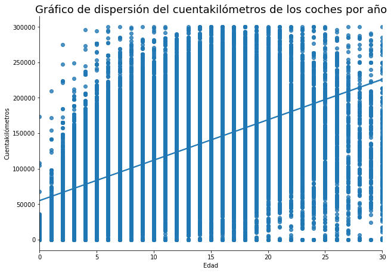

```python
import seaborn as sns

sns.lmplot( x='age', y='odometer', data=df[['age','odometer']], height = 6, aspect = 1.5)
plt.title('Gráfico de dispersión del cuentakilómetros de los coches por año', fontsize = 18)
plt.xlabel('Edad')
plt.ylabel('Cuentakilómetros');
```

|  | As Pandas [documentation](https://pandas.pydata.org/pandas-docs/stable/reference/api/pandas.DataFrame.groupby.html) clarifies, in order to group by a function on a column, you need to set first that c… |
| --- | --- |

Hay que tener en cuenta que los coches de kilómetro cero los descartamos, por ello nuetro curva deberá empezar en 10000 millas.

```python
# Tal y como nos indican arriba, agrupamos por múltiplos de 10000 millas:

def agrupacion(millas):
    n = 0
    for valor in range(10000, 300001, 10000):
        if millas > n and millas <= valor:
            return valor
        n == valor
    return
```

Calculamos el precio medio del cuentakilómetros (agrupar por múltiplos de 10000 millas):

```python
df.groupby(df['odometer'].apply(agrupacion).sort_values(ascending = False))['price'].mean()
```

```
odometer
10000     20135.979294
20000     27016.921267
30000     24424.418533
40000     22328.629934
50000     19585.643914
60000     17855.371557
70000     16129.750137
80000     14347.962592
90000     13374.957180
100000    12377.918561
110000    11225.051525
120000    10032.652627
130000     9740.624133
140000     8696.668370
```

[output cut: 17 more lines]

Lo graficamos:

```python
df.groupby(df['odometer'].apply(agrupacion).sort_values(ascending = False))['price'].mean().plot(color = "#819FF7",
                                         fontsize = 12,
                                         title = 'Precio medio vs Millas',
                                         xlabel = 'Millas',
                                         ylabel = 'Precio medio', colorbar = 'purple'
                                        )
```

[interactive chart not shown]

Los coches con menos de 10000 millas tienen un precio medio de 20000 dólares, mientras que los tienen entre 10000 y 20000 millas tienen un precio medio de 27000 dólares.

Puede entenderse que el aumento del precio de los coches de 10000 a 20000 millas es debido a que son los que presentan una mayor demanda en el mercado de segunda mano. De ahí el incremento de valor y a partir de ahí su precio comienza a descender, siendo lo más normal, a mayor cuentakilómetros, menor precio del coche.

```python
# Extraemos precio y millas:
df_millas_precio = df [['odometer', 'price']].copy()

# agrupamos por millas y obtenemos el precio medio; Establecemos esa columna como índice con set_index:
df_millas_precio = df_millas_precio.groupby(df['odometer'].apply(agrupacion).sort_values(ascending = False))['price'].mean().reset_index()

# Utilizamos pct_change() para calcular la depreciación:
df_millas_precio["Depreciación"] = df_millas_precio ['price'].pct_change()
df_millas_precio["Depreciación"] = df_millas_precio ["Depreciación"] * 100

df_millas_precio
```

|  | odometer | price | Depreciación |
| --- | --- | --- | --- |
| 0 | 10000 | 20135.979294 | NaN |
| 1 | 20000 | 27016.921267 | 34.172373 |
| 2 | 30000 | 24424.418533 | -9.595848 |
| 3 | 40000 | 22328.629934 | -8.580710 |
| 4 | 50000 | 19585.643914 | -12.284614 |
| 5 | 60000 | 17855.371557 | -8.834391 |
| 6 | 70000 | 16129.750137 | -9.664439 |
| 7 | 80000 | 14347.962592 | -11.046591 |
| 8 | 90000 | 13374.957180 | -6.781488 |
| 9 | 100000 | 12377.918561 | -7.454518 |
| 10 | 110000 | 11225.051525 | -9.313901 |
| 11 | 120000 | 10032.652627 | -10.622659 |
| 12 | 130000 | 9740.624133 | -2.910780 |
| 13 | 140000 | 8696.668370 | -10.717545 |
| 14 | 150000 | 8157.864556 | -6.195520 |
| 15 | 160000 | 7782.058454 | -4.606672 |
| 16 | 170000 | 7687.409355 | -1.216248 |
| 17 | 180000 | 6990.205278 | -9.069428 |
| 18 | 190000 | 7421.873822 | 6.175334 |
| 19 | 200000 | 6474.933759 | -12.758773 |
| 20 | 210000 | 6445.087129 | -0.460957 |
| 21 | 220000 | 5699.513441 | -11.568093 |
| 22 | 230000 | 5847.221077 | 2.591583 |
| 23 | 240000 | 6442.864048 | 10.186770 |
| 24 | 250000 | 6098.072993 | -5.351518 |
| 25 | 260000 | 5914.944751 | -3.003051 |
| 26 | 270000 | 6985.743590 | 18.103277 |
| 27 | 280000 | 7474.760417 | 7.000212 |
| 28 | 290000 | 5290.118919 | -29.226910 |
| 29 | 300000 | 5959.919463 | 12.661351 |

Para que la gráfica comience en 10000 y no en cero millas:

```python
media_df_millas_precio = df_millas_precio.drop(range(0, 1),axis=0)
media_df_millas_precio
```

|  | odometer | price | Depreciación |
| --- | --- | --- | --- |
| 1 | 20000 | 27016.921267 | 34.172373 |
| 2 | 30000 | 24424.418533 | -9.595848 |
| 3 | 40000 | 22328.629934 | -8.580710 |
| 4 | 50000 | 19585.643914 | -12.284614 |
| 5 | 60000 | 17855.371557 | -8.834391 |
| 6 | 70000 | 16129.750137 | -9.664439 |
| 7 | 80000 | 14347.962592 | -11.046591 |
| 8 | 90000 | 13374.957180 | -6.781488 |
| 9 | 100000 | 12377.918561 | -7.454518 |
| 10 | 110000 | 11225.051525 | -9.313901 |
| 11 | 120000 | 10032.652627 | -10.622659 |
| 12 | 130000 | 9740.624133 | -2.910780 |
| 13 | 140000 | 8696.668370 | -10.717545 |
| 14 | 150000 | 8157.864556 | -6.195520 |
| 15 | 160000 | 7782.058454 | -4.606672 |
| 16 | 170000 | 7687.409355 | -1.216248 |
| 17 | 180000 | 6990.205278 | -9.069428 |
| 18 | 190000 | 7421.873822 | 6.175334 |
| 19 | 200000 | 6474.933759 | -12.758773 |
| 20 | 210000 | 6445.087129 | -0.460957 |
| 21 | 220000 | 5699.513441 | -11.568093 |
| 22 | 230000 | 5847.221077 | 2.591583 |
| 23 | 240000 | 6442.864048 | 10.186770 |
| 24 | 250000 | 6098.072993 | -5.351518 |
| 25 | 260000 | 5914.944751 | -3.003051 |
| 26 | 270000 | 6985.743590 | 18.103277 |
| 27 | 280000 | 7474.760417 | 7.000212 |
| 28 | 290000 | 5290.118919 | -29.226910 |
| 29 | 300000 | 5959.919463 | 12.661351 |

Para poder comparar con la gráfica del estudio, observemos la media de millas para 20 años:

```python
df.groupby(['age'])['odometer'].mean()
```

```
age
0       9935.638507
1      21274.701655
2      39658.377352
3      51384.301370
4      69812.165013
5      82549.903293
6      93158.250395
7     102821.692821
8     112230.394527
9     122322.966534
10    126845.794208
11    130436.452450
12    135783.645592
13    142255.470206
```

[output cut: 18 more lines]

La media para 20 años es de 158.455 millas.

```python
df_millas_precio_depr = df_millas_precio.drop(range(16, 30),axis=0)
df_millas_precio_depr
```

|  | odometer | price | Depreciación |
| --- | --- | --- | --- |
| 0 | 10000 | 20135.979294 | NaN |
| 1 | 20000 | 27016.921267 | 34.172373 |
| 2 | 30000 | 24424.418533 | -9.595848 |
| 3 | 40000 | 22328.629934 | -8.580710 |
| 4 | 50000 | 19585.643914 | -12.284614 |
| 5 | 60000 | 17855.371557 | -8.834391 |
| 6 | 70000 | 16129.750137 | -9.664439 |
| 7 | 80000 | 14347.962592 | -11.046591 |
| 8 | 90000 | 13374.957180 | -6.781488 |
| 9 | 100000 | 12377.918561 | -7.454518 |
| 10 | 110000 | 11225.051525 | -9.313901 |
| 11 | 120000 | 10032.652627 | -10.622659 |
| 12 | 130000 | 9740.624133 | -2.910780 |
| 13 | 140000 | 8696.668370 | -10.717545 |
| 14 | 150000 | 8157.864556 | -6.195520 |
| 15 | 160000 | 7782.058454 | -4.606672 |

```python
df_millas_precio_depr['Depreciación'].mean()
```

```
-5.629153570364212
```

Depreciación = 5.62 % cada 10000 millas (de media)

Vemos la gráfica:

```python
df_millas_precio_depr.groupby(['odometer'])['price'].mean().plot(color = "#819FF7",
                                         fontsize = 12,
                                         title = 'Curva depreciación Precio vs Millas del coche',
                                         xlabel = 'Millas',
                                         ylabel = 'Precio medio', colorbar = True
                                        )
```

[interactive chart not shown]

El primer año no sabemos cúanto se deprecia realmente. La depreciación media para el resto de años difiere un poco con el anterior.

Fair enough, as this confirms that our clean data follow the expected trend. Once we rely on our data, it's time to split them into training and testing sets:

|  | Divide `df` into: * `X` (information of cars excluding `price`). * `Y` (`price` of those cars). Use 80% of cars for training, and the remaining 20% for testing, **Remember to use `RANDOM_STATE`** so t… |
| --- | --- |

```python
# Coordenada x:
X = df.loc[:, df.columns != 'price']

# Y ahora la coordenada y, es decir, el target,
y = df.loc[:, df.columns == 'price']
```

```python
X
```

|  | odometer | manufacturer_acura | manufacturer_alfa-romeo | manufacturer_aston-martin | manufacturer_audi | manufacturer_bmw | manufacturer_buick | manufacturer_cadillac | manufacturer_chevrolet | manufacturer_chrysler | ... | paint_color_custom | paint_color_green | paint_color_grey | paint_color_orange | paint_color_purple | paint_color_red | paint_color_silver | paint_color_white | paint_color_yellow | age |
| --- | --- | --- | --- | --- | --- | --- | --- | --- | --- | --- | --- | --- | --- | --- | --- | --- | --- | --- | --- | --- | --- |
| 0 | 254217 | 0 | 0 | 0 | 0 | 0 | 0 | 0 | 0 | 0 | ... | 0 | 0 | 0 | 0 | 0 | 0 | 0 | 1 | 0 | 13 |
| 1 | 188406 | 0 | 0 | 0 | 0 | 0 | 0 | 0 | 0 | 0 | ... | 0 | 0 | 1 | 0 | 0 | 0 | 0 | 0 | 0 | 8 |
| 2 | 108124 | 0 | 0 | 0 | 0 | 0 | 0 | 0 | 1 | 0 | ... | 0 | 0 | 1 | 0 | 0 | 0 | 0 | 0 | 0 | 10 |
| 3 | 178054 | 0 | 0 | 0 | 0 | 0 | 0 | 0 | 1 | 0 | ... | 0 | 0 | 0 | 0 | 0 | 0 | 0 | 1 | 0 | 9 |
| 4 | 170259 | 0 | 0 | 0 | 0 | 0 | 0 | 0 | 0 | 0 | ... | 0 | 0 | 0 | 0 | 0 | 0 | 0 | 1 | 0 | 6 |
| ... | ... | ... | ... | ... | ... | ... | ... | ... | ... | ... | ... | ... | ... | ... | ... | ... | ... | ... | ... | ... | ... |
| 77875 | 82000 | 0 | 0 | 0 | 0 | 0 | 0 | 0 | 0 | 0 | ... | 0 | 0 | 0 | 0 | 0 | 0 | 1 | 0 | 0 | 8 |
| 77876 | 40000 | 0 | 0 | 0 | 0 | 0 | 0 | 0 | 0 | 0 | ... | 0 | 0 | 0 | 0 | 0 | 0 | 0 | 0 | 0 | 18 |
| 77877 | 58000 | 0 | 0 | 0 | 0 | 0 | 0 | 0 | 0 | 0 | ... | 0 | 0 | 0 | 0 | 0 | 0 | 0 | 0 | 0 | 18 |
| 77878 | 159980 | 0 | 0 | 0 | 0 | 0 | 0 | 0 | 0 | 0 | ... | 0 | 0 | 0 | 0 | 0 | 0 | 0 | 0 | 0 | 14 |
| 77879 | 160000 | 0 | 0 | 0 | 0 | 0 | 0 | 0 | 0 | 0 | ... | 0 | 1 | 0 | 0 | 0 | 0 | 0 | 0 | 0 | 17 |

77880 rows × 97 columns

```python
y
```

|  | price |
| --- | --- |
| 0 | 16995 |
| 1 | 13995 |
| 2 | 7995 |
| 3 | 8995 |
| 4 | 10995 |
| ... | ... |
| 77875 | 9885 |
| 77876 | 750 |
| 77877 | 4800 |
| 77878 | 1600 |
| 77879 | 9000 |

77880 rows × 1 columns

```python
train, test = train_test_split(df,
                               train_size = 0.80,
                               random_state = 42) # Fijamos la semilla
```

```python
target = 'price'
indp_columns = [x for x in df.columns if x !='price']
```

```python
X_train = train[indp_columns]
y_train = train[target]
```

```python
X_test = test[indp_columns]
y_test = test[target]
```

```python
X_train
```

|  | odometer | manufacturer_acura | manufacturer_alfa-romeo | manufacturer_aston-martin | manufacturer_audi | manufacturer_bmw | manufacturer_buick | manufacturer_cadillac | manufacturer_chevrolet | manufacturer_chrysler | ... | paint_color_custom | paint_color_green | paint_color_grey | paint_color_orange | paint_color_purple | paint_color_red | paint_color_silver | paint_color_white | paint_color_yellow | age |
| --- | --- | --- | --- | --- | --- | --- | --- | --- | --- | --- | --- | --- | --- | --- | --- | --- | --- | --- | --- | --- | --- |
| 29645 | 72500 | 0 | 0 | 0 | 0 | 0 | 0 | 0 | 1 | 0 | ... | 0 | 0 | 0 | 0 | 0 | 0 | 0 | 1 | 0 | 4 |
| 68355 | 136000 | 0 | 0 | 0 | 0 | 0 | 0 | 0 | 0 | 0 | ... | 0 | 0 | 1 | 0 | 0 | 0 | 0 | 0 | 0 | 17 |
| 52304 | 109526 | 0 | 0 | 0 | 0 | 0 | 0 | 0 | 1 | 0 | ... | 0 | 0 | 0 | 0 | 0 | 0 | 0 | 0 | 0 | 8 |
| 62400 | 184850 | 0 | 0 | 0 | 0 | 0 | 0 | 0 | 0 | 0 | ... | 1 | 0 | 0 | 0 | 0 | 0 | 0 | 0 | 0 | 14 |
| 11259 | 70000 | 0 | 0 | 0 | 0 | 0 | 0 | 0 | 0 | 0 | ... | 0 | 0 | 0 | 0 | 0 | 0 | 0 | 0 | 0 | 4 |
| ... | ... | ... | ... | ... | ... | ... | ... | ... | ... | ... | ... | ... | ... | ... | ... | ... | ... | ... | ... | ... | ... |
| 6265 | 58457 | 0 | 0 | 0 | 0 | 0 | 0 | 0 | 0 | 0 | ... | 0 | 0 | 0 | 0 | 0 | 0 | 0 | 0 | 0 | 2 |
| 54886 | 215000 | 0 | 0 | 0 | 0 | 0 | 0 | 0 | 1 | 0 | ... | 0 | 0 | 0 | 0 | 0 | 0 | 1 | 0 | 0 | 15 |
| 76820 | 138600 | 0 | 0 | 0 | 0 | 0 | 0 | 0 | 0 | 0 | ... | 0 | 0 | 0 | 0 | 0 | 0 | 0 | 0 | 0 | 13 |
| 860 | 80000 | 0 | 0 | 0 | 0 | 0 | 0 | 0 | 1 | 0 | ... | 0 | 0 | 0 | 0 | 0 | 0 | 0 | 1 | 0 | 7 |
| 15795 | 53171 | 0 | 0 | 0 | 0 | 0 | 0 | 0 | 0 | 0 | ... | 0 | 0 | 0 | 0 | 0 | 1 | 0 | 0 | 0 | 3 |

62304 rows × 97 columns

```python
y_train
```

```
29645    24495
68355     6500
52304     7300
62400     3995
11259    31900
         ...
6265     12900
54886     8995
76820     3300
860       8299
15795    40990
Name: price, Length: 62304, dtype: int32
```

So that now we can train a very basic model:

|  | Use `age` to train a linear regression model, that is, find values for `w` and `b` such that the estimated price is $\hat{y} = w·age + b$. Which values do you obtain for `w` and `b`? Can you explain i… |
| --- | --- |

|  | Check the documentation of [LinearRegression](https://scikit-learn.org/stable/modules/generated/sklearn.linear_model.LinearRegression.html?highlight=linearregression#sklearn-linear-model-linearregress… |
| --- | --- |

### Regresión lineal:

```python
lr =  LinearRegression(fit_intercept=True) # Añadimos intercept, bias

# LLamamos al método fit para entrenar la regresión:
lr.fit (X_train [['age']], y_train)
```

```
LinearRegression()
```

```python
print("beta 0 o intercepto (b): " + str(lr.intercept_))
print("beta 1 (w): " + str(lr.coef_))
```

```
beta 0 o intercepto (b): 22095.42478817676
beta 1 (w): [-962.26429718]
```

Hemos usado una regresión lineal para encontrar los parámetros de la línea que minimiza el error de los datos que tenemos. El proceso de aprendizaje consiste en estimar los parámetros w y b. Así nos queda que para estos datos, los mejores valores son:

w = -962.2642971829098

b = 22095.42478817676

Nuestra modelo de regresión lineal es el siguiente: ŷ = -962.26429718.age + 22095.424788176766

El w nos indica la pendiente de la recta, su grado de inclinación, al ser un valor negativo nos está informando de que la recta es decreciente. Nos está indicando que los coches se van depreciando cada año en 962,26 dólares.

El b es el valor que toma la variable dependiente "y", cuando la variable independiente "x" vale 0, y es el punto donde la recta cruza el eje vertical. En nuestro caso, nos indica que la recta corta al eje vertical (precio) en 0 años, con un valor de 22095.42 dólares.

En el año 0 el valor que obteníamos de precio era de 30033.95 dólares, aquí nos da un valor de 22095.42 dólares. Difieren en casi 8000 dólares.

Vamos a visualizarlo:

```python
año_precio = train.groupby(['age'])['price'].mean()
año_precio = año_precio.values
train_Pmedio = pd.DataFrame()
train_Pmedio['Edad'] = np.arange(0, 31)
train_Pmedio['Precio'] = año_precio
```

```python
X_train_Pmedio = train_Pmedio['Edad'].values
y_train_Pmedio = train_Pmedio['Precio'].values
```

```python
w = -962.26429718
b = 22095.424788176766
```

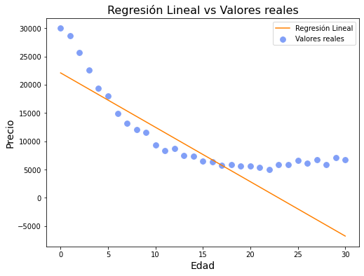

```python
plt.figure(figsize=(8,6))

plt.scatter(X_train_Pmedio, y_train_Pmedio, c='#819FF7', s=60, label='Valores reales')

# La función lineal:
plt.plot ( X_train_Pmedio, w*X_train_Pmedio + b, color='#FF8000', label="Regresión Lineal")

plt.title("Regresión Lineal vs Valores reales", fontsize = 16)
plt.xlabel("Edad", fontsize = 14)
plt.ylabel("Precio", fontsize = 14)
plt.legend();
```

And check it out in test:

|  | Use the linear regression model to predict for `X_test` cars. What score do you obtain? How does this compare to `X_train` cars? Why is this? |
| --- | --- |

|  | A good way to grasp what is going on is to plot with two different line plots: * What the model says for a given `age`. * The average price in the dataset for that `age`. Do this either for `X_train` … |
| --- | --- |

Aplicamos ".score", que por defecto es el R2(coeficiente de determinación), que no es muy recomendable como medida del rendimiento. El R2 es muy sensible al número de datos.

Lo probamos de todos modos:

```python
print ("Train score (R2): ", lr.score(X_train [['age']], y_train))
```

```
Train score (R2):  0.3399370598042252
```

```python
print ("Test score (R2): ", lr.score(X_test [['age']], y_test))
```

```
Test score (R2):  0.33662203506125643
```

En problemas de regresión, recomiendan utilizar otro tipo de métricas, como puede ser el error cuadrático medio (MSE), o bien la raíz de este valor (RMSE), o el error absoluto medio (MAE, el más estable cuando se tienen outliers en la muestra).

```python
from sklearn.metrics import mean_squared_error
from sklearn.metrics import mean_absolute_error

# Medimos el MSE en el conjunto de testing.
mse = mean_squared_error(y_true = y_test, y_pred = lr.predict(X_test[["age"]]).reshape(-1, 1))

# Calculamos el RMSE:
rmse = np.sqrt(mse)

# Calculamos el MAE:
mae = mean_absolute_error(y_true = y_test, y_pred = lr.predict(X_test[["age"]]).reshape(-1, 1))

print ("Train score (R2): ", lr.score(X_train [['age']], y_train))
print("MSE test: " + str(mse))
print("RMSE test: " +  str(rmse))
print("MAE test: " +  str(mae))
```

```
Train score (R2):  0.3399370598042252
MSE test: 60487159.02335366
RMSE test: 7777.349100005326
MAE test: 5876.8384209432525
```

El RMSE se puede entender como, en términos medios, fallamos las predicciones por unos 7777 dólares en el precio del coche, ya sea de más o de menos, sobre el valor real.

```python
prediccion = pd.DataFrame({'age': np.arange(0,31)})
prediccion['price'] = lr.predict(prediccion[['age']])
```

```python
linea1 = df.groupby(['age'])['price'].mean().plot (x = 'age', y = 'price', color = "#FF8000",
                                         fontsize = 12,
                                         title = 'Predicción vs Precio medio por edad',
                                         xlabel = 'Edad',
                                         ylabel = 'Precio')
linea2 = prediccion.plot (x = 'age', y = 'price', kind = 'line', color = "#819FF7")
linea1 * linea2
```

[interactive chart not shown]

Si nos situamos sobre la línea de predicción vemos cómo a partir del año 23 las predicciones muestran valores negativos; no tienen sentido precios de coche negativos.

Let's repeat this with `odometer`:

|  | Use `odometer` to train another linear regression model, that is, find values for `w` and `b` such that the estimated price is $\hat{y} = w·odometer + b$. Which values do you obtain now for `w` and `b… |
| --- | --- |

```python
# Coordenada x:
X = df.loc[:, df.columns != 'price']

# Y ahora la coordenada y, es decir, el target,
y = df.loc[:, df.columns == 'price']
```

```python
target = 'price'
indp_columns = [x for x in df.columns if x !='price']

X_train = train[indp_columns]
y_train = train[target]
```

```python
lr_millas =  LinearRegression(fit_intercept=True) # Añadimos intercept, bias
```

```python
# LLamamos al método fit para entrenar la regresión:
lr_millas.fit (X_train [['odometer']], y_train)
```

```
LinearRegression()
```

```python
print("beta 0 o intercepto (b): " + str(lr_millas.intercept_))
print("beta 1 (w): " + str(lr_millas.coef_))
```

```
beta 0 o intercepto (b): 22022.011181975868
beta 1 (w): [-0.08524899]
```

Como en el caso anterior, al ser w un valor negativo, tendremos una función lineal decreciente. Los coches se deprecian por milla adicional en 0.085 dólares.

Aquí obtenemos un w menor que para 'age'; esto tiene sentido, puesto que aquí estamos hablando de millas, y es lógico que el valor monetario sea menor al hablar de milla a milla, que de año a año.

La recta corta al eje vertical (precio) en 0 años, con un valor de 22022.01 dólares.

En el año 0 el valor que obteníamos de precio era de 20135.97 dólares, aquí nos da un valor de 22022.01 dólares. Difieren en casi 2000 dólares. (Recordemos que nosotros no teníamos en cuenta ese valor, sino que empezábamos en 1000 millas)

Lo vemos gráficamente:

```python
millas_precio = train.groupby(train['odometer'].apply(agrupacion).sort_values(ascending = False))['price'].mean()
millas_precio = millas_precio.values
train_Pmedio_millas = pd.DataFrame()
train_Pmedio_millas['Millas'] = np.arange(10000, 310000, 10000)
train_Pmedio_millas['Precio'] = millas_precio
```

```python
X_train = train_Pmedio_millas['Millas'].values
y_train = train_Pmedio_millas['Precio'].values
```

```python
w = -0.08524899
b = 22022.011181975868
```

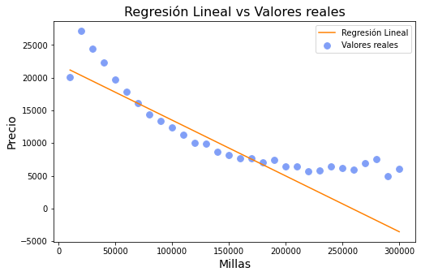

```python
plt.figure(figsize=(8,5))

plt.scatter(X_train, y_train, c='#819FF7', s=60, label='Valores reales')

# La función lineal:
plt.plot ( X_train, w*X_train + b, color='#FF8000', label="Regresión Lineal")

plt.title("Regresión Lineal vs Valores reales", fontsize = 16)
plt.xlabel("Millas", fontsize = 14)
plt.ylabel("Precio", fontsize = 14)
plt.legend();
```

```python
X_test = test['odometer'].values
y_test = test['price'].values

print("Train score (R2): " + str(lr_millas.score(X_train.reshape(-1, 1), y_train)))
```

```
Train score (R2): 0.543426251374703
```

```python
X_test = test['odometer'].values
y_test = test['price'].values

print("Test score (R2): "  + str(lr_millas.score(X_test.reshape(-1, 1), y_test)))
```

```
Test score (R2): 0.27603497477336525
```

```python
# Medimos el MSE en el conjunto de training.
mse = mean_squared_error(y_true=y_test, y_pred=lr_millas.predict(X_test.reshape(-1, 1)))

# Calculamos el RMSE
rmse = np.sqrt(mse)

# Calculamos el MAE:
mae = mean_absolute_error(y_true = y_test, y_pred = lr_millas.predict(X_test.reshape(-1, 1)))

print("Test score (R2): " + str(lr_millas.score(X_test.reshape(-1, 1), y_test)))
print("MSE test: " + str(mse))
print("RMSE test: " +  str(rmse))
print("MAE test: " +  str(mae))
```

```
Test score (R2): 0.27603497477336525
MSE test: 66011519.7107479
RMSE test: 8124.747362887531
MAE test: 6072.1001050681225
```

El RMSE viene a indicarnos que fallamos las predicciones por unos 8124 dólares en el precio del coche, sobre el valor real. (Para la edad RMSE era de 7777 dólares)

Vemos como los resultados muestran cómo el kilometraje predice peor que la antigüedad. Tanto si nos fijamos en el R2 como si nos fijamos en el RMSE.

```python
prediccion2 = pd.DataFrame({'odometer': np.arange(10000, 310000, 10000)})
prediccion2['price'] = lr_millas.predict(prediccion2[['odometer']])
```

```python
linea1 = df_millas_precio.groupby(['odometer'])['price'].mean().plot(color = "#FF8000",
                                         fontsize = 12,
                                         title = 'Predicción vs Precio medio por millas',
                                         xlabel = 'Millas',
                                         ylabel = 'Precio', colorbar = True)
linea2 = prediccion2.plot (x = 'odometer', y = 'price', kind = 'line', color ="#819FF7")
linea1 * linea2
```

[interactive chart not shown]

En la figura se aprecia como para 260000 el precio del vehículo es negativo. Lo que no tiene sentido.

Como ya vimos, el score RMSE es mejor para la feature 'age' que para la 'odometer'.

One of the problems with the above linear regressions is that we are taking into account just one variable (either `age` or `odometer`) to predict. But there are many more features in the dataset, including all the categorical ones. Let's fit a tree to see what happens:

|  | Train a decision tree with all features (use `max_depth=5` to try to prevent overfitting) and store it in a variable called `dt`. Do you obtain better predictions now in test? |
| --- | --- |

```python
target = 'price'
indp_columns = [x for x in df.columns if x !='price']

X_train = train[indp_columns]
y_train = train[target]

X_test = test[indp_columns]
y_test = test[target]
```

```python
# Formulamos árbol:
dt = DecisionTreeRegressor(criterion="mse", # Al ser árboles regresores, no usan gini o entropía, sino MSE
                                 max_depth=5,
                                 min_samples_split=5,
                                 min_samples_leaf=5
                                )

# Entrenamos:
dt.fit(X_train, y_train)

# Medimos:
mse_dt = mean_squared_error(y_true = y_test, y_pred = dt.predict(X_test))
rmse_dt = np.sqrt(mse_dt)

print("MSE: " + str(mse_dt))
print("RMSE: " +  str(rmse_dt))
```

```
MSE: 28367308.870631143
RMSE: 5326.0969640658195
```

Veamos el resultado:

Mejora con respecto del RMSE obtenido en regresión lineal que era de 7777 dólares. Hemos conseguido reducir el error en las predicciones en 2451 dólares (7777 - 5326).

One of the advantages of decision trees is that their nodes can be plot to see how the tree is deciding to split. This can be done using the `plot_tree` utility function. For example, the first levels can be shown as follows:

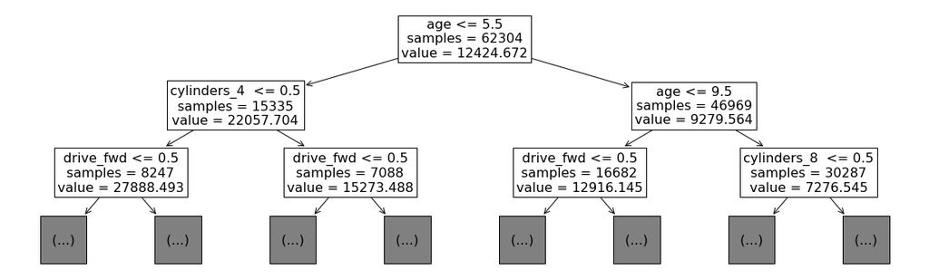

```python
_, ax = plt.subplots(figsize=(20, 6))
plot_tree(dt, max_depth=2, ax=ax, feature_names=X_train.columns, impurity=False, fontsize=16);
```

Which shows that depending on the branch the price prediction (`value`) differs notably. The features that are selected most times to split are reflected in the `feature_importances_` field:

|  | Plot the importance of the 10 most important features. Which are those features? Does this make sense according to your intuition? |
| --- | --- |

|  | You may find the [`argsort`](https://numpy.org/doc/stable/reference/generated/numpy.argsort.html?highlight=argsort#numpy.argsort) function useful when trying to obtain the most important features. Onc… |
| --- | --- |

```python
dt.feature_importances_
```

```
array([0.05797833, 0.        , 0.        , 0.        , 0.        ,
       0.        , 0.        , 0.        , 0.        , 0.        ,
       0.        , 0.        , 0.        , 0.        , 0.        ,
       0.        , 0.        , 0.        , 0.        , 0.        ,
       0.        , 0.        , 0.        , 0.        , 0.        ,
       0.        , 0.        , 0.        , 0.        , 0.        ,
       0.        , 0.        , 0.        , 0.        , 0.        ,
       0.        , 0.        , 0.        , 0.        , 0.        ,
       0.        , 0.        , 0.        , 0.        , 0.        ,
       0.        , 0.        , 0.        , 0.00101937, 0.15162408,
       0.        , 0.01146445, 0.02964704, 0.        , 0.04182367,
       0.        , 0.        , 0.        , 0.        , 0.        ,
       0.        , 0.        , 0.        , 0.        , 0.        ,
       0.        , 0.        , 0.        , 0.        , 0.10835136,
       0.00535401, 0.00183525, 0.        , 0.        , 0.        ,
       0.        , 0.        , 0.        , 0.        , 0.        ,
       0.        , 0.        , 0.        , 0.        , 0.        ,
       0.        , 0.        , 0.        , 0.        , 0.        ,
       0.        , 0.        , 0.        , 0.        , 0.        ,
       0.        , 0.59090243])
```

```python
# Ordenamos de menor a mayor importancia:

orden = dt.feature_importances_.argsort()
orden
```

```
array([46, 66, 65, 64, 63, 62, 61, 60, 59, 67, 58, 56, 55, 53, 50, 94, 95,
       47, 91, 57, 45, 68, 72, 90, 89, 88, 87, 86, 85, 84, 83, 93, 82, 80,
       79, 78, 77, 76, 75, 74, 73, 81, 44, 92, 42, 20, 19, 18, 17, 16, 15,
       14, 13, 12, 43, 11,  9,  8,  7,  6,  5,  4,  3,  2,  1, 10, 22, 21,
       24, 41, 40, 39, 38, 37, 36, 35, 23, 33, 34, 31, 30, 29, 28, 27, 26,
       25, 32, 48, 71, 70, 51, 52, 54,  0, 69, 49, 96], dtype=int64)
```

```python
features_importances = pd.DataFrame(columns = X_train.columns[orden])
features_importances
```

|  | cylinders_10 | transmission_manual | transmission_automatic | title_status_salvage | title_status_rebuilt | title_status_parts only | title_status_missing | title_status_lien | title_status_clean | transmission_other | ... | cylinders_3 | type_SUV | drive_rwd | cylinders_6 | cylinders_8 | fuel_diesel | odometer | drive_fwd | cylinders_4 | age |
| --- | --- | --- | --- | --- | --- | --- | --- | --- | --- | --- | --- | --- | --- | --- | --- | --- | --- | --- | --- | --- | --- |

0 rows × 97 columns

#### Top 10 de las características más importantes

```python
features_importances.loc[0]=dt.feature_importances_[orden]
features_importances
```

|  | cylinders_10 | transmission_manual | transmission_automatic | title_status_salvage | title_status_rebuilt | title_status_parts only | title_status_missing | title_status_lien | title_status_clean | transmission_other | ... | cylinders_3 | type_SUV | drive_rwd | cylinders_6 | cylinders_8 | fuel_diesel | odometer | drive_fwd | cylinders_4 | age |
| --- | --- | --- | --- | --- | --- | --- | --- | --- | --- | --- | --- | --- | --- | --- | --- | --- | --- | --- | --- | --- | --- |
| 0 | 0.0 | 0.0 | 0.0 | 0.0 | 0.0 | 0.0 | 0.0 | 0.0 | 0.0 | 0.0 | ... | 0.001019 | 0.001835 | 0.005354 | 0.011464 | 0.029647 | 0.041824 | 0.057978 | 0.108351 | 0.151624 | 0.590902 |

1 rows × 97 columns

```python
Top_fi = features_importances.drop(features_importances.columns[0: 87], axis='columns')
Top_fi
```

|  | cylinders_3 | type_SUV | drive_rwd | cylinders_6 | cylinders_8 | fuel_diesel | odometer | drive_fwd | cylinders_4 | age |
| --- | --- | --- | --- | --- | --- | --- | --- | --- | --- | --- |
| 0 | 0.001019 | 0.001835 | 0.005354 | 0.011464 | 0.029647 | 0.041824 | 0.057978 | 0.108351 | 0.151624 | 0.590902 |

```python
Top_fi.plot.bar(fontsize = 12,
                title = 'Top Características regresoras del árbol de decisión según su Importancia',
                xlabel = 'Características del árbol de decisión',
                ylabel = 'Importancia')
```

[interactive chart not shown]

En un primer momento pensaría que las características más importantes serían la antiguedad y el número de millas recorridas por un vehículo. (En este ranking ocupan el 1º y 4º puesto)

Le daría escasa importancia al color (tal y como refleja el gráfico, dada su ausencia).

Es importante que sea impulsado por diesel, la cilindrada, la tracción y el hecho de ser SUV.

## Ensemble models

The model in `dt` should have convinced you that trees show predictive power for this dataset, but that it's not enough with a single tree. Time now to try tree ensembles:

|  | Train tree ensembles on this dataset. Feel free to edit this notebook and to try different: * Techniques (bagging, boosting, ...). * Implementations (sklearn, xgb, ...). * Parameter selections (number… |
| --- | --- |

```python
from sklearn.ensemble import RandomForestRegressor
from sklearn.ensemble import ExtraTreesRegressor
from sklearn.ensemble import AdaBoostRegressor
from sklearn.ensemble import GradientBoostingRegressor

# Implementaciones gb especializadas
from lightgbm import LGBMRegressor   # lightgbm
from catboost import CatBoostRegressor   # catboost

from xgboost import XGBRegressor


from sklearn.model_selection import GridSearchCV
```

Modelos que instanciaremos:

- Bagging : RandomForestRegressor
- ExtraTreesRegressor
- Boosting : AdaBoostRegressor
- GradientBoostingRegressor
- LGBMRegressor
- CatBoostRegressor
- XGBRegressor

```python
rf_reg = RandomForestRegressor(random_state = RANDOM_STATE)
extree_reg = ExtraTreesRegressor(random_state = RANDOM_STATE)
ab_reg = AdaBoostRegressor(random_state = RANDOM_STATE)
gb_reg = GradientBoostingRegressor(random_state = RANDOM_STATE)
lgb_reg = LGBMRegressor(random_state = RANDOM_STATE)
cb_reg = CatBoostRegressor(random_state = RANDOM_STATE)
xgb_reg = XGBRegressor(random_state = RANDOM_STATE)
```

```python
modelos = [
    ('rf_reg', RandomForestRegressor()), ('extree_reg', ExtraTreesRegressor()), ('ab_reg', AdaBoostRegressor()),
    ('gb_reg', GradientBoostingRegressor()), ('lgb_reg', LGBMRegressor()),
    ('cb_reg', CatBoostRegressor(), ('xgb_reg'), XGBRegressor())]
```

Dado que en clase se comentó como referencia el obtener aproximadamente un R2 de 0.88 / 0.90, será esta medida la que utilizaremos para guiarnos.

Al ser árboles, no hay estandarización.

### Bagging : Random Forest Regressor

```python
rf_reg = RandomForestRegressor (n_estimators = 300,
          max_depth = 30,
          min_samples_split = 10,
          ccp_alpha = 0.1,
          min_samples_leaf = 5)


rf_reg.fit(X_train, y_train)


print('score train: ', rf_reg.score (X_train, y_train))
print('score test: ', rf_reg.score (X_test, y_test))
```

```
score train:  0.9261439647269304
score test:  0.87047476559512
```

Está sobreajustando. Probemos otra combinación de parámetros, reduciendo el número de árboles.

```python
rf_reg2 = RandomForestRegressor(n_estimators = 150,
           max_depth = 30,
           max_features = "sqrt",
           ccp_alpha = 0.1,
           min_samples_split =  10,
           min_samples_leaf = 5
         )

rf_reg2.fit(X_train, y_train)


print('score train: ', rf_reg2.score (X_train, y_train))
print('score test: ', rf_reg2.score (X_test, y_test))
```

```
score train:  0.8520101608269286
score test:  0.8301924174133274
```

No mejora el score, pero conseguimos rebajar el sobreajuste.

```python
rf_reg3 = RandomForestRegressor(n_estimators = 150,
           max_depth = 10,
           max_features = "sqrt",
           ccp_alpha = 0.1,
           min_samples_split = 10,
           min_samples_leaf = 5
         )

rf_reg3.fit(X_train, y_train)


print('score train: ', rf_reg3.score (X_train, y_train))
print('score test: ', rf_reg3.score (X_test, y_test))
```

```
score train:  0.7463269438817786
score test:  0.7373589316770175
```

A la vez que lanzo un RandomForest tiro un ExtraTrees, porque normalmente funciona muy bien

### ExtraTrees Regressor

```python
extree_reg = ExtraTreesRegressor (n_estimators = 300,
          max_depth = 30,
          max_features = "sqrt",
          min_samples_split = 10,
          ccp_alpha = 0.1,
          min_samples_leaf = 5)


extree_reg.fit(X_train, y_train)


print('score train: ', extree_reg.score (X_train, y_train))
print('score test: ', extree_reg.score (X_test, y_test))
```

```
score train:  0.8003343419389614
score test:  0.7772280661308425
```

```python
extree_reg2 = ExtraTreesRegressor(n_estimators = 150,
           max_depth = 30,
           max_features = "sqrt",
           ccp_alpha = 0.1,
           min_samples_split =  2,
           min_samples_leaf = 1
         )

extree_reg2.fit(X_train, y_train)


print('score train: ', extree_reg2.score (X_train, y_train))
print('score test: ', extree_reg2.score (X_test, y_test))
```

```
score train:  0.9757574411364947
score test:  0.8746782538803057
```

En esta segunda opción, reducimos número de árboles y, aunque aumenta el score, aumenta también el sobreajuste.

### Boosting : AdaBoost Regressor

```python
# Grid de hiperparámetros:
grid_ab_reg = {"n_estimators": [150, 300, 500],
               "learning_rate": [1.0]
              }

# GridSearch:
gs_ab_reg = GridSearchCV(estimator = ab_reg,
                        param_grid = grid_ab_reg,
                        scoring    = 'r2',
                        n_jobs=-1,
                        cv=10,
                        verbose=1)

gs_ab_reg.fit(X_train, y_train)

print('Mejor selección: ', gs_ab_reg.best_estimator_)
print('Score train: ', gs_ab_reg.best_score_)
```

```
Fitting 10 folds for each of 3 candidates, totalling 30 fits
Mejor selección:  AdaBoostRegressor(n_estimators=150, random_state=42)
Score train:  0.5339653564125568
```

### - GradientBoosting Regressor

```python
# Grid de hiperparámetros:
grid_gb_reg  = {"learning_rate": [0.1, 0.5],
                "n_estimators": [50,100],
                "min_samples_split": [1, 5],
                "min_samples_leaf": [2, 4],
                "max_depth": [1,5,9],
                }

# GridSearch:
gs_gb_reg = GridSearchCV(estimator = gb_reg,
                        param_grid = grid_gb_reg,
                        scoring    = 'r2',
                        n_jobs=-1,
                        cv=10,
                        verbose=1)

gs_gb_reg.fit(X_train, y_train)

print('Mejor selección: ', gs_gb_reg.best_estimator_)
print('Score train: ', gs_gb_reg.best_score_)
```

```
Fitting 10 folds for each of 48 candidates, totalling 480 fits
Mejor selección:  GradientBoostingRegressor(max_depth=9, min_samples_leaf=2, min_samples_split=5,
                          random_state=42)
Score train:  0.882432818235037
```

```python
print('score test: ', gs_gb_reg.score (X_test, y_test))
```

```
score test:  0.8806076896727612
```

### - Lightgbm

```python
# Grid de hiperparámetros:
grid_lgb_reg = {"num_leaves": [7, 14, 21, 28, 31, 50],
                "learning_rate": [0.1, 0.03],
                "n_estimators": [150,300],
                "max_depth": [-1,3,5,9,11],
                }

# GridSearch:
gs_lgb_reg = GridSearchCV(estimator = lgb_reg,
                        param_grid = grid_lgb_reg,
                        scoring    = 'r2',
                        n_jobs=-1,
                        cv=10,
                        verbose=1)

gs_lgb_reg.fit(X_train, y_train)

print('Mejor selección: ', gs_lgb_reg.best_estimator_)
print('Score train: ', gs_lgb_reg.best_score_)
```

```
Fitting 10 folds for each of 120 candidates, totalling 1200 fits
Mejor selección:  LGBMRegressor(n_estimators=300, num_leaves=50, random_state=42)
Score train:  0.8815811343287233
```

### - Catboost

```python
# No hay estandarización:

# Grid de hiperparámetros:
grid_cb_reg = {"iterations": [100, 200, 300],
               "learning_rate": [0.03, 0.1, 0.5],
               "depth": [3, 9],
               "random_strength": [0.2, 0.5, 1, 3]
                }

# GridSearch:
gs_cb_reg = GridSearchCV(estimator = cb_reg,
                        param_grid = grid_cb_reg,
                        scoring    = 'r2',
                        n_jobs=-1,
                        cv=10,
                        verbose=1)

gs_cb_reg.fit(X_train, y_train)

print('Mejor selección: ', gs_cb_reg.best_estimator_)
print('Score train: ', gs_cb_reg.best_score_)
```

[output not shown]

[output cut: 248 more lines]

[output not shown]

```python
print('score test: ', gs_cb_reg.score (X_test, y_test))
```

```
score test:  0.8863943961051888
```

```python
mse = mean_squared_error(y_true=y_test,
                         y_pred=gs_cb_reg.predict(X_test))

rmse = np.sqrt(mse)

print("El modelo Catboost Regressor tiene un RMSE en el conjunto de test de "  +  str(rmse))
```

```
El modelo Catboost Regressor tiene un RMSE en el conjunto de test de 3218.481001984796
```

### XGBoost Regressor

```python
# No hay estandarización:

# Grid de hiperparámetros:
grid_xgb_reg = {"n_estimators": [100, 300],
                "max_depth": [3, 9, 11],
                "subsample": [0.03, 0.1, 0.5],
                "learning_rate": [0.03, 0.1],
                "colsample_bytree": [0.3, 0.7]
               }

# GridSearch:
gs_xgb_reg = GridSearchCV(estimator = xgb_reg,
                        param_grid = grid_xgb_reg,
                        scoring    = 'r2',
                        n_jobs=-1,
                        cv=10,
                        verbose=1)

gs_xgb_reg.fit(X_train, y_train)

print('Mejor selección: ', gs_xgb_reg.best_estimator_)
print('Score train: ', gs_xgb_reg.best_score_, 2)
```

```
Fitting 10 folds for each of 72 candidates, totalling 720 fits
Mejor selección:  XGBRegressor(base_score=0.5, booster='gbtree', callbacks=None,
             colsample_bylevel=1, colsample_bynode=1, colsample_bytree=0.7,
             early_stopping_rounds=None, enable_categorical=False,
             eval_metric=None, gamma=0, gpu_id=-1, grow_policy='depthwise',
             importance_type=None, interaction_constraints='',
             learning_rate=0.1, max_bin=256, max_cat_to_onehot=4,
             max_delta_step=0, max_depth=11, max_leaves=0, min_child_weight=1,
             missing=nan, monotone_constraints='()', n_estimators=300, n_jobs=0,
             num_parallel_tree=1, predictor='auto', random_state=42,
             reg_alpha=0, reg_lambda=1, ...)
Score train:  0.8946653044286901 2
```

```python
from sklearn.metrics import r2_score

r2 = r2_score(y_true=y_test,
                         y_pred=gs_xgb_reg .predict(X_test))

mse = mean_squared_error(y_true=y_test,
                         y_pred=gs_xgb_reg.predict(X_test))

rmse = np.sqrt(mse)

print("El modelo XGBoost Regressor tiene un R2 en el conjunto de test de "  +  str(r2))
print("El modelo XGBoost Regressor tiene un RMSE en el conjunto de test de "  +  str(rmse))
```

```
El modelo XGBoost Regressor tiene un R2 en el conjunto de test de 0.8955386594657713
El modelo XGBoost Regressor tiene un RMSE en el conjunto de test de 3086.2341319462994
```

Una vez que tenemos todos los modelos, vamos a ver cuál el es que mejor puntuación obtiene.

Para ello agrupo todos los GridSearchCV :

```python
conjunto_de_GridSearchs = [gs_ab_reg ,
                            gs_gb_reg ,
                            gs_lgb_reg ,
                            gs_cb_reg ,
                            gs_xgb_reg ]
```

```python
best_score = [gs_ab_reg.best_score_, gs_gb_reg.best_score_, gs_lgb_reg.best_score_, gs_cb_reg.best_score_,
              gs_xgb_reg.best_score_]
```

```python
best_score
```

```
[0.5339653564125568,
 0.882432818235037,
 0.8815811343287233,
 0.8861127541000705,
 0.8946653044286901]
```

Ha ganado el XGBoost Regressor. Vamos a ver con qué argumentos/hiperparámetros ha ganado:

```python
mejor_puntuación_GridSearch = conjunto_de_GridSearchs[4].best_estimator_
mejor_puntuación_GridSearch
```

```
XGBRegressor(base_score=0.5, booster='gbtree', callbacks=None,
             colsample_bylevel=1, colsample_bynode=1, colsample_bytree=0.7,
             early_stopping_rounds=None, enable_categorical=False,
             eval_metric=None, gamma=0, gpu_id=-1, grow_policy='depthwise',
             importance_type=None, interaction_constraints='',
             learning_rate=0.1, max_bin=256, max_cat_to_onehot=4,
             max_delta_step=0, max_depth=11, max_leaves=0, min_child_weight=1,
             missing=nan, monotone_constraints='()', n_estimators=300, n_jobs=0,
             num_parallel_tree=1, predictor='auto', random_state=42,
             reg_alpha=0, reg_lambda=1, ...)
```

Y de los generados, este es el modelo que querríamos utilizar para hacer nuestras predicciones a futuro.

Con el XBGBoost se obtiene un RMSE en test de 3086.23.

En regresión lineal el RMSE era de 7777 dólares.

En el árbol de 5326. [Reducción del error en las predicciones en 2451 dólares (7777 - 5326)]

Hemos conseguido reducir el error en las predicciones en 4691 dólares (7777 - 3086) con respecto de la regresión lineal y en 2240 dólares con respecto del árbol de regresión.

|  | Plot the importance of the 10 most important features for the best model you find. Which are those features? Are they the same and in the same proportion than for `dt`? Why/why not? |
| --- | --- |

```python
gs_xgb_reg = gs_xgb_reg.best_estimator_

gs_xgb_reg.feature_importances_
```

```
array([0.00850621, 0.00644123, 0.00246151, 0.0028461 , 0.00837195,
       0.00893748, 0.00279712, 0.0101903 , 0.00504659, 0.00549118,
       0.00777315, 0.00602403, 0.00493246, 0.00472091, 0.00216029,
       0.00576139, 0.00466388, 0.00356117, 0.01068352, 0.0106494 ,
       0.00674356, 0.00151136, 0.01442832, 0.0068323 , 0.00273688,
       0.00985618, 0.01007318, 0.00160005, 0.00744689, 0.00677646,
       0.00259152, 0.00533027, 0.00604528, 0.01236681, 0.00255531,
       0.00613593, 0.02109064, 0.00989019, 0.00456131, 0.0090001 ,
       0.00291376, 0.01195992, 0.00474376, 0.00467026, 0.00485647,
       0.0062207 , 0.01544354, 0.01021937, 0.01176102, 0.07746497,
       0.00386711, 0.01010429, 0.0618461 , 0.00621643, 0.06060211,
       0.0079291 , 0.02001475, 0.00864348, 0.008644  , 0.00331471,
       0.00400752, 0.00109472, 0.0024955 , 0.00830475, 0.00651765,
       0.00622559, 0.00599378, 0.00914908, 0.01375489, 0.10401107,
       0.00373915, 0.00633885, 0.01270296, 0.01154476, 0.00532203,
       0.00492733, 0.00518345, 0.01232973, 0.00515097, 0.01360542,
       0.01271877, 0.01985563, 0.01315192, 0.0024394 , 0.0032689 ,
       0.0026259 , 0.00302807, 0.00317947, 0.0025979 , 0.00292538,
       0.00352727, 0.00241106, 0.00266797, 0.00269819, 0.00396862,
       0.00337204, 0.06213599], dtype=float32)
```

```python
len(gs_xgb_reg.feature_importances_)
```

```
97
```

```python
sort = gs_xgb_reg.feature_importances_.argsort()
```

```python
features_importance = pd.DataFrame(columns = X_train.columns[sort])
features_importance
```

|  | title_status_missing | manufacturer_land rover | manufacturer_mini | manufacturer_harley-davidson | paint_color_purple | type_wagon | manufacturer_alfa-romeo | title_status_parts only | manufacturer_saturn | manufacturer_pontiac | ... | manufacturer_lexus | cylinders_10 | type_truck | fuel_gas | manufacturer_tesla | fuel_diesel | cylinders_8 | age | cylinders_4 | drive_fwd |
| --- | --- | --- | --- | --- | --- | --- | --- | --- | --- | --- | --- | --- | --- | --- | --- | --- | --- | --- | --- | --- | --- |

0 rows × 97 columns

```python
features_importance.loc[0] = gs_xgb_reg.feature_importances_[sort]
features_importance
```

|  | title_status_missing | manufacturer_land rover | manufacturer_mini | manufacturer_harley-davidson | paint_color_purple | type_wagon | manufacturer_alfa-romeo | title_status_parts only | manufacturer_saturn | manufacturer_pontiac | ... | manufacturer_lexus | cylinders_10 | type_truck | fuel_gas | manufacturer_tesla | fuel_diesel | cylinders_8 | age | cylinders_4 | drive_fwd |
| --- | --- | --- | --- | --- | --- | --- | --- | --- | --- | --- | --- | --- | --- | --- | --- | --- | --- | --- | --- | --- | --- |
| 0 | 0.001095 | 0.001511 | 0.0016 | 0.00216 | 0.002411 | 0.002439 | 0.002462 | 0.002495 | 0.002555 | 0.002592 | ... | 0.014428 | 0.015444 | 0.019856 | 0.020015 | 0.021091 | 0.060602 | 0.061846 | 0.062136 | 0.077465 | 0.104011 |

1 rows × 97 columns

```python
Top_fi = features_importance.drop(features_importance.columns[0: 87], axis='columns')
Top_fi
```

|  | manufacturer_lexus | cylinders_10 | type_truck | fuel_gas | manufacturer_tesla | fuel_diesel | cylinders_8 | age | cylinders_4 | drive_fwd |
| --- | --- | --- | --- | --- | --- | --- | --- | --- | --- | --- |
| 0 | 0.014428 | 0.015444 | 0.019856 | 0.020015 | 0.021091 | 0.060602 | 0.061846 | 0.062136 | 0.077465 | 0.104011 |

```python
Top_fi.plot.bar(fontsize = 12, rot=35,
                title = 'Top Características regresoras del XGBoost según su Importancia',
                xlabel = 'XGBoost Regressor Features',
                ylabel = 'Importancia'
               )
```

[interactive chart not shown]

En esta ocasión, a diferencia del primer gráfico que vimos para el árbol de decisión, todas las características tienen valor de importancia distinto a cero.

A mayores en esta última se aprecia que las 10 primeras tienen un valor de importancia menor que en el árbol de decisión, en el que la de mayor importancia tenía un valor próximo a 0.6). Esto tiene su lógica, si se piensa en que la importancia ahora se reparte entre más features.

|  | Compute the predictions for your best model, and plot them against the real prices in `Y_test`. Are you surprised by the results? Do the same for `Y_train` and see if the behavior has degraded conside… |
| --- | --- |

### - Train :

```python
predXgboost_train = gs_xgb_reg.predict(X_train)

predXgboost_train
```

```
array([21183.033 ,  7413.956 ,  8125.0513, ...,  4099.09  ,  6967.992 ,
       39163.66  ], dtype=float32)
```

```python
predXgboost_train_df = X_train
```

```python
predXgboost_train_df["predXgboost_train"] = predXgboost_train
```

```python
predXgboost_train_df.head()
```

|  | odometer | manufacturer_acura | manufacturer_alfa-romeo | manufacturer_aston-martin | manufacturer_audi | manufacturer_bmw | manufacturer_buick | manufacturer_cadillac | manufacturer_chevrolet | manufacturer_chrysler | ... | paint_color_green | paint_color_grey | paint_color_orange | paint_color_purple | paint_color_red | paint_color_silver | paint_color_white | paint_color_yellow | age | predXgboost_train |
| --- | --- | --- | --- | --- | --- | --- | --- | --- | --- | --- | --- | --- | --- | --- | --- | --- | --- | --- | --- | --- | --- |
| 29645 | 72500 | 0 | 0 | 0 | 0 | 0 | 0 | 0 | 1 | 0 | ... | 0 | 0 | 0 | 0 | 0 | 0 | 1 | 0 | 4 | 21183.033203 |
| 68355 | 136000 | 0 | 0 | 0 | 0 | 0 | 0 | 0 | 0 | 0 | ... | 0 | 1 | 0 | 0 | 0 | 0 | 0 | 0 | 17 | 7413.956055 |
| 52304 | 109526 | 0 | 0 | 0 | 0 | 0 | 0 | 0 | 1 | 0 | ... | 0 | 0 | 0 | 0 | 0 | 0 | 0 | 0 | 8 | 8125.051270 |
| 62400 | 184850 | 0 | 0 | 0 | 0 | 0 | 0 | 0 | 0 | 0 | ... | 0 | 0 | 0 | 0 | 0 | 0 | 0 | 0 | 14 | 6088.878906 |
| 11259 | 70000 | 0 | 0 | 0 | 0 | 0 | 0 | 0 | 0 | 0 | ... | 0 | 0 | 0 | 0 | 0 | 0 | 0 | 0 | 4 | 31100.562500 |

5 rows × 98 columns

#### Precios reales vs predicción:

```python
predXgboost_train_df['price'] = y_train
```

```python
predXgboost_train_df.head()
```

|  | odometer | manufacturer_acura | manufacturer_alfa-romeo | manufacturer_aston-martin | manufacturer_audi | manufacturer_bmw | manufacturer_buick | manufacturer_cadillac | manufacturer_chevrolet | manufacturer_chrysler | ... | paint_color_grey | paint_color_orange | paint_color_purple | paint_color_red | paint_color_silver | paint_color_white | paint_color_yellow | age | predXgboost_train | price |
| --- | --- | --- | --- | --- | --- | --- | --- | --- | --- | --- | --- | --- | --- | --- | --- | --- | --- | --- | --- | --- | --- |
| 29645 | 72500 | 0 | 0 | 0 | 0 | 0 | 0 | 0 | 1 | 0 | ... | 0 | 0 | 0 | 0 | 0 | 1 | 0 | 4 | 21183.033203 | 24495 |
| 68355 | 136000 | 0 | 0 | 0 | 0 | 0 | 0 | 0 | 0 | 0 | ... | 1 | 0 | 0 | 0 | 0 | 0 | 0 | 17 | 7413.956055 | 6500 |
| 52304 | 109526 | 0 | 0 | 0 | 0 | 0 | 0 | 0 | 1 | 0 | ... | 0 | 0 | 0 | 0 | 0 | 0 | 0 | 8 | 8125.051270 | 7300 |
| 62400 | 184850 | 0 | 0 | 0 | 0 | 0 | 0 | 0 | 0 | 0 | ... | 0 | 0 | 0 | 0 | 0 | 0 | 0 | 14 | 6088.878906 | 3995 |
| 11259 | 70000 | 0 | 0 | 0 | 0 | 0 | 0 | 0 | 0 | 0 | ... | 0 | 0 | 0 | 0 | 0 | 0 | 0 | 4 | 31100.562500 | 31900 |

5 rows × 99 columns

```python
predXgboost_train_df["diferencia"] = predXgboost_train_df["predXgboost_train"] - y_train
```

```python
predXgboost_train_df = predXgboost_train_df.sort_values(by = "price", ascending = False)
```

```python
predXgboost_train_df
```

|  | odometer | manufacturer_acura | manufacturer_alfa-romeo | manufacturer_aston-martin | manufacturer_audi | manufacturer_bmw | manufacturer_buick | manufacturer_cadillac | manufacturer_chevrolet | manufacturer_chrysler | ... | paint_color_orange | paint_color_purple | paint_color_red | paint_color_silver | paint_color_white | paint_color_yellow | age | predXgboost_train | price | diferencia |
| --- | --- | --- | --- | --- | --- | --- | --- | --- | --- | --- | --- | --- | --- | --- | --- | --- | --- | --- | --- | --- | --- |
| 72777 | 4700 | 0 | 0 | 0 | 0 | 0 | 0 | 0 | 1 | 0 | ... | 0 | 0 | 0 | 0 | 0 | 0 | 0 | 47788.996094 | 50000 | -2211.003906 |
| 21483 | 57100 | 0 | 0 | 0 | 0 | 0 | 0 | 0 | 0 | 0 | ... | 0 | 0 | 0 | 0 | 0 | 0 | 4 | 47048.597656 | 50000 | -2951.402344 |
| 66009 | 22500 | 0 | 0 | 0 | 0 | 0 | 0 | 0 | 0 | 0 | ... | 0 | 0 | 0 | 0 | 0 | 0 | 4 | 45468.957031 | 50000 | -4531.042969 |
| 71181 | 7900 | 0 | 0 | 0 | 0 | 0 | 0 | 0 | 0 | 0 | ... | 0 | 0 | 0 | 0 | 0 | 0 | 1 | 48136.656250 | 50000 | -1863.343750 |
| 55346 | 2236 | 0 | 0 | 0 | 0 | 0 | 0 | 0 | 1 | 0 | ... | 0 | 0 | 1 | 0 | 0 | 0 | 5 | 46978.820312 | 50000 | -3021.179688 |
| ... | ... | ... | ... | ... | ... | ... | ... | ... | ... | ... | ... | ... | ... | ... | ... | ... | ... | ... | ... | ... | ... |
| 47868 | 44995 | 0 | 0 | 0 | 0 | 0 | 0 | 0 | 0 | 0 | ... | 0 | 0 | 0 | 0 | 1 | 0 | 7 | 2019.084839 | 500 | 1519.084839 |
| 47918 | 44995 | 0 | 0 | 0 | 0 | 0 | 0 | 0 | 0 | 0 | ... | 0 | 0 | 0 | 0 | 1 | 0 | 7 | 2019.084839 | 500 | 1519.084839 |
| 14672 | 192000 | 0 | 0 | 0 | 0 | 0 | 0 | 0 | 0 | 0 | ... | 0 | 0 | 0 | 0 | 0 | 0 | 17 | 3399.289307 | 500 | 2899.289307 |
| 26146 | 140007 | 0 | 0 | 0 | 0 | 0 | 1 | 0 | 0 | 0 | ... | 0 | 0 | 0 | 0 | 1 | 0 | 21 | 595.701904 | 500 | 95.701904 |
| 38105 | 197000 | 0 | 0 | 0 | 0 | 0 | 0 | 0 | 0 | 0 | ... | 0 | 0 | 0 | 0 | 0 | 0 | 19 | 1410.272705 | 500 | 910.272705 |

62304 rows × 100 columns

```python
predXgboost_train_df.reset_index(drop=True, inplace=True)
predXgboost_train_df
```

|  | odometer | manufacturer_acura | manufacturer_alfa-romeo | manufacturer_aston-martin | manufacturer_audi | manufacturer_bmw | manufacturer_buick | manufacturer_cadillac | manufacturer_chevrolet | manufacturer_chrysler | ... | paint_color_orange | paint_color_purple | paint_color_red | paint_color_silver | paint_color_white | paint_color_yellow | age | predXgboost_train | price | diferencia |
| --- | --- | --- | --- | --- | --- | --- | --- | --- | --- | --- | --- | --- | --- | --- | --- | --- | --- | --- | --- | --- | --- |
| 0 | 4700 | 0 | 0 | 0 | 0 | 0 | 0 | 0 | 1 | 0 | ... | 0 | 0 | 0 | 0 | 0 | 0 | 0 | 47788.996094 | 50000 | -2211.003906 |
| 1 | 57100 | 0 | 0 | 0 | 0 | 0 | 0 | 0 | 0 | 0 | ... | 0 | 0 | 0 | 0 | 0 | 0 | 4 | 47048.597656 | 50000 | -2951.402344 |
| 2 | 22500 | 0 | 0 | 0 | 0 | 0 | 0 | 0 | 0 | 0 | ... | 0 | 0 | 0 | 0 | 0 | 0 | 4 | 45468.957031 | 50000 | -4531.042969 |
| 3 | 7900 | 0 | 0 | 0 | 0 | 0 | 0 | 0 | 0 | 0 | ... | 0 | 0 | 0 | 0 | 0 | 0 | 1 | 48136.656250 | 50000 | -1863.343750 |
| 4 | 2236 | 0 | 0 | 0 | 0 | 0 | 0 | 0 | 1 | 0 | ... | 0 | 0 | 1 | 0 | 0 | 0 | 5 | 46978.820312 | 50000 | -3021.179688 |
| ... | ... | ... | ... | ... | ... | ... | ... | ... | ... | ... | ... | ... | ... | ... | ... | ... | ... | ... | ... | ... | ... |
| 62299 | 44995 | 0 | 0 | 0 | 0 | 0 | 0 | 0 | 0 | 0 | ... | 0 | 0 | 0 | 0 | 1 | 0 | 7 | 2019.084839 | 500 | 1519.084839 |
| 62300 | 44995 | 0 | 0 | 0 | 0 | 0 | 0 | 0 | 0 | 0 | ... | 0 | 0 | 0 | 0 | 1 | 0 | 7 | 2019.084839 | 500 | 1519.084839 |
| 62301 | 192000 | 0 | 0 | 0 | 0 | 0 | 0 | 0 | 0 | 0 | ... | 0 | 0 | 0 | 0 | 0 | 0 | 17 | 3399.289307 | 500 | 2899.289307 |
| 62302 | 140007 | 0 | 0 | 0 | 0 | 0 | 1 | 0 | 0 | 0 | ... | 0 | 0 | 0 | 0 | 1 | 0 | 21 | 595.701904 | 500 | 95.701904 |
| 62303 | 197000 | 0 | 0 | 0 | 0 | 0 | 0 | 0 | 0 | 0 | ... | 0 | 0 | 0 | 0 | 0 | 0 | 19 | 1410.272705 | 500 | 910.272705 |

62304 rows × 100 columns

```python
from bokeh.io import output_notebook, show
output_notebook()

from bokeh.plotting import Figure
```

```python
train = Figure(title = 'TRAIN : Precio real vs Predicciones', width=800, height=400, tools=['pan',
                               'xwheel_zoom',
                               'hover',
                               'reset',
                               'help'])
train.scatter(x = predXgboost_train, y = y_train, size=10, fill_color='#819FF7')

train.yaxis.axis_label='Predicciones'
train.xaxis.axis_label='Real'
show(train)
```

[interactive chart not shown]

Sacamos la desviación absoluta media:

```python
predXgboost_train_df["diferencia"].mad()
```

```
1197.7137464011973
```

### - Test :

```python
predXgboost_test = gs_xgb_reg.predict(X_test)

predXgboost_test
```

```
array([ 4582.972 , 12354.122 , 26921.434 , ..., 11489.902 , 16048.394 ,
        6659.9326], dtype=float32)
```

```python
predXgboost_test_df = X_test
```

```python
predXgboost_test_df['predXgboost_test'] = predXgboost_test
```

```python
predXgboost_test_df.head()
```

|  | odometer | manufacturer_acura | manufacturer_alfa-romeo | manufacturer_aston-martin | manufacturer_audi | manufacturer_bmw | manufacturer_buick | manufacturer_cadillac | manufacturer_chevrolet | manufacturer_chrysler | ... | paint_color_green | paint_color_grey | paint_color_orange | paint_color_purple | paint_color_red | paint_color_silver | paint_color_white | paint_color_yellow | age | predXgboost_test |
| --- | --- | --- | --- | --- | --- | --- | --- | --- | --- | --- | --- | --- | --- | --- | --- | --- | --- | --- | --- | --- | --- |
| 27026 | 159427 | 0 | 0 | 0 | 0 | 0 | 0 | 0 | 0 | 0 | ... | 0 | 0 | 0 | 0 | 0 | 1 | 0 | 0 | 11 | 4582.972168 |
| 31692 | 153164 | 0 | 0 | 0 | 1 | 0 | 0 | 0 | 0 | 0 | ... | 0 | 0 | 0 | 0 | 0 | 0 | 0 | 0 | 10 | 12354.122070 |
| 1520 | 151318 | 0 | 0 | 0 | 0 | 0 | 0 | 0 | 0 | 0 | ... | 0 | 0 | 0 | 0 | 0 | 0 | 1 | 0 | 5 | 26921.433594 |
| 59465 | 75700 | 0 | 0 | 0 | 0 | 0 | 0 | 0 | 0 | 0 | ... | 0 | 0 | 0 | 0 | 0 | 1 | 0 | 0 | 7 | 15179.643555 |
| 67441 | 191588 | 1 | 0 | 0 | 0 | 0 | 0 | 0 | 0 | 0 | ... | 0 | 0 | 0 | 0 | 0 | 0 | 0 | 0 | 17 | 4649.409180 |

5 rows × 98 columns

#### Precios reales vs predicción:

```python
predXgboost_test_df['price'] = y_test
```

```python
predXgboost_test_df.head()
```

|  | odometer | manufacturer_acura | manufacturer_alfa-romeo | manufacturer_aston-martin | manufacturer_audi | manufacturer_bmw | manufacturer_buick | manufacturer_cadillac | manufacturer_chevrolet | manufacturer_chrysler | ... | paint_color_grey | paint_color_orange | paint_color_purple | paint_color_red | paint_color_silver | paint_color_white | paint_color_yellow | age | predXgboost_test | price |
| --- | --- | --- | --- | --- | --- | --- | --- | --- | --- | --- | --- | --- | --- | --- | --- | --- | --- | --- | --- | --- | --- |
| 27026 | 159427 | 0 | 0 | 0 | 0 | 0 | 0 | 0 | 0 | 0 | ... | 0 | 0 | 0 | 0 | 1 | 0 | 0 | 11 | 4582.972168 | 5890 |
| 31692 | 153164 | 0 | 0 | 0 | 1 | 0 | 0 | 0 | 0 | 0 | ... | 0 | 0 | 0 | 0 | 0 | 0 | 0 | 10 | 12354.122070 | 9995 |
| 1520 | 151318 | 0 | 0 | 0 | 0 | 0 | 0 | 0 | 0 | 0 | ... | 0 | 0 | 0 | 0 | 0 | 1 | 0 | 5 | 26921.433594 | 23999 |
| 59465 | 75700 | 0 | 0 | 0 | 0 | 0 | 0 | 0 | 0 | 0 | ... | 0 | 0 | 0 | 0 | 1 | 0 | 0 | 7 | 15179.643555 | 11900 |
| 67441 | 191588 | 1 | 0 | 0 | 0 | 0 | 0 | 0 | 0 | 0 | ... | 0 | 0 | 0 | 0 | 0 | 0 | 0 | 17 | 4649.409180 | 3800 |

5 rows × 99 columns

```python
predXgboost_test_df['diferencia'] = predXgboost_test_df['predXgboost_test'] - y_test
```

```python
predXgboost_test_df = predXgboost_test_df.sort_values(by ='price', ascending = False)
```

```python
predXgboost_test_df
```

|  | odometer | manufacturer_acura | manufacturer_alfa-romeo | manufacturer_aston-martin | manufacturer_audi | manufacturer_bmw | manufacturer_buick | manufacturer_cadillac | manufacturer_chevrolet | manufacturer_chrysler | ... | paint_color_orange | paint_color_purple | paint_color_red | paint_color_silver | paint_color_white | paint_color_yellow | age | predXgboost_test | price | diferencia |
| --- | --- | --- | --- | --- | --- | --- | --- | --- | --- | --- | --- | --- | --- | --- | --- | --- | --- | --- | --- | --- | --- |
| 53007 | 2315 | 0 | 0 | 0 | 0 | 0 | 0 | 0 | 0 | 0 | ... | 0 | 0 | 0 | 0 | 1 | 0 | 0 | 38061.593750 | 50000 | -11938.406250 |
| 42034 | 1800 | 0 | 0 | 0 | 0 | 0 | 0 | 0 | 0 | 0 | ... | 0 | 0 | 0 | 0 | 0 | 0 | 0 | 42720.414062 | 50000 | -7279.585938 |
| 63242 | 136600 | 0 | 0 | 0 | 0 | 0 | 0 | 0 | 0 | 0 | ... | 0 | 0 | 0 | 0 | 0 | 0 | 4 | 43349.339844 | 50000 | -6650.660156 |
| 70819 | 10500 | 0 | 0 | 0 | 0 | 0 | 0 | 1 | 0 | 0 | ... | 0 | 0 | 0 | 0 | 0 | 0 | 3 | 30167.867188 | 50000 | -19832.132812 |
| 25341 | 47000 | 0 | 0 | 0 | 0 | 0 | 0 | 0 | 0 | 0 | ... | 0 | 0 | 0 | 0 | 1 | 0 | 2 | 32360.837891 | 49999 | -17638.162109 |
| ... | ... | ... | ... | ... | ... | ... | ... | ... | ... | ... | ... | ... | ... | ... | ... | ... | ... | ... | ... | ... | ... |
| 48518 | 44995 | 0 | 0 | 0 | 0 | 0 | 0 | 0 | 0 | 0 | ... | 0 | 0 | 0 | 0 | 1 | 0 | 7 | 2019.084839 | 500 | 1519.084839 |
| 41212 | 2520 | 0 | 0 | 0 | 0 | 0 | 0 | 1 | 0 | 0 | ... | 0 | 0 | 0 | 0 | 1 | 0 | 2 | 36413.101562 | 500 | 35913.101562 |
| 74640 | 44995 | 0 | 0 | 0 | 0 | 0 | 0 | 0 | 0 | 0 | ... | 0 | 0 | 0 | 0 | 1 | 0 | 7 | 2019.084839 | 500 | 1519.084839 |
| 68171 | 205000 | 0 | 0 | 0 | 0 | 0 | 0 | 0 | 0 | 0 | ... | 0 | 0 | 0 | 0 | 1 | 0 | 18 | 2593.081055 | 500 | 2093.081055 |
| 36515 | 160000 | 0 | 0 | 0 | 0 | 0 | 1 | 0 | 0 | 0 | ... | 0 | 0 | 1 | 0 | 0 | 0 | 17 | 409.691040 | 500 | -90.308960 |

15576 rows × 100 columns

```python
predXgboost_test_df.reset_index(drop=True, inplace=True)
predXgboost_test_df
```

|  | odometer | manufacturer_acura | manufacturer_alfa-romeo | manufacturer_aston-martin | manufacturer_audi | manufacturer_bmw | manufacturer_buick | manufacturer_cadillac | manufacturer_chevrolet | manufacturer_chrysler | ... | paint_color_orange | paint_color_purple | paint_color_red | paint_color_silver | paint_color_white | paint_color_yellow | age | predXgboost_test | price | diferencia |
| --- | --- | --- | --- | --- | --- | --- | --- | --- | --- | --- | --- | --- | --- | --- | --- | --- | --- | --- | --- | --- | --- |
| 0 | 2315 | 0 | 0 | 0 | 0 | 0 | 0 | 0 | 0 | 0 | ... | 0 | 0 | 0 | 0 | 1 | 0 | 0 | 38061.593750 | 50000 | -11938.406250 |
| 1 | 1800 | 0 | 0 | 0 | 0 | 0 | 0 | 0 | 0 | 0 | ... | 0 | 0 | 0 | 0 | 0 | 0 | 0 | 42720.414062 | 50000 | -7279.585938 |
| 2 | 136600 | 0 | 0 | 0 | 0 | 0 | 0 | 0 | 0 | 0 | ... | 0 | 0 | 0 | 0 | 0 | 0 | 4 | 43349.339844 | 50000 | -6650.660156 |
| 3 | 10500 | 0 | 0 | 0 | 0 | 0 | 0 | 1 | 0 | 0 | ... | 0 | 0 | 0 | 0 | 0 | 0 | 3 | 30167.867188 | 50000 | -19832.132812 |
| 4 | 47000 | 0 | 0 | 0 | 0 | 0 | 0 | 0 | 0 | 0 | ... | 0 | 0 | 0 | 0 | 1 | 0 | 2 | 32360.837891 | 49999 | -17638.162109 |
| ... | ... | ... | ... | ... | ... | ... | ... | ... | ... | ... | ... | ... | ... | ... | ... | ... | ... | ... | ... | ... | ... |
| 15571 | 44995 | 0 | 0 | 0 | 0 | 0 | 0 | 0 | 0 | 0 | ... | 0 | 0 | 0 | 0 | 1 | 0 | 7 | 2019.084839 | 500 | 1519.084839 |
| 15572 | 2520 | 0 | 0 | 0 | 0 | 0 | 0 | 1 | 0 | 0 | ... | 0 | 0 | 0 | 0 | 1 | 0 | 2 | 36413.101562 | 500 | 35913.101562 |
| 15573 | 44995 | 0 | 0 | 0 | 0 | 0 | 0 | 0 | 0 | 0 | ... | 0 | 0 | 0 | 0 | 1 | 0 | 7 | 2019.084839 | 500 | 1519.084839 |
| 15574 | 205000 | 0 | 0 | 0 | 0 | 0 | 0 | 0 | 0 | 0 | ... | 0 | 0 | 0 | 0 | 1 | 0 | 18 | 2593.081055 | 500 | 2093.081055 |
| 15575 | 160000 | 0 | 0 | 0 | 0 | 0 | 1 | 0 | 0 | 0 | ... | 0 | 0 | 1 | 0 | 0 | 0 | 17 | 409.691040 | 500 | -90.308960 |

15576 rows × 100 columns

```python
test = Figure(title = 'TEST : Precio real vs Predicciones', width=800, height=400, tools=['pan',
                               'xwheel_zoom',
                               'hover',
                               'reset',
                               'help'])
test.scatter(x = predXgboost_test, y = y_test, size=10, fill_color='#819FF7')

test.yaxis.axis_label='Predicciones'
test.xaxis.axis_label='Real'
show(test)
```

[interactive chart not shown]

Sacamos la desviación absoluta media:

```python
predXgboost_test_df["diferencia"].mad()
```

```
1853.7840021937825
```

#### - Veamos la variación:

El conjunto de datos que tiene un valor más alto de desviación media absoluta(o desviación absoluta) tiene más variabilidad. Es preferible el conjunto de datos con un valor más bajo de desviación media absoluta(o desviación absoluta). -> mad(train) = 1197.71 y mad(test) = 1853.78 -> Por ello, en nuestro caso, los resultados de las predicciones para train son mejores que para test.

```python
round(predXgboost_test_df["diferencia"].mad() - predXgboost_train_df["diferencia"].mad(), 2)
```

```
656.07
```

Intuitivamente, si la predicción fuera perfecta, el gráfico 'Real vs Predicción' debería ser la recta de 45 gradaos. Mi gráfica es una desviación de esa recta, una correlación positiva. A mayor precio real mi modelo predice un mayor precio (aunque se equivoque de vez en cuando).

En ambos casos para precios en la zona central, la tendencia es a nivelarse tanto por exceso como por defecto.

Se observan valores extremos de predicciones erróneas más en test que en train.

La gráfica para train parace más uniforme y a la de test parece que le afectan más tanto los aciertos como los errores.

|  | Find some examples of the following: 1. Cars whose price are very underestimated by the model. 2. Cars whose price are very overestimated by the model. 3. Cars whose price are almost predicted exactly… |
| --- | --- |

El RMSE (Root Mean Square Error): se utiliza para comparar la precisión de diferentes métodos de pronóstico.

Podemos entenderlo como los fallos en la predicciones que tiene el modelo cuando predice el precio del coche, en términos medios.

```python
predXgboost_test_df
```

|  | odometer | manufacturer_acura | manufacturer_alfa-romeo | manufacturer_aston-martin | manufacturer_audi | manufacturer_bmw | manufacturer_buick | manufacturer_cadillac | manufacturer_chevrolet | manufacturer_chrysler | ... | paint_color_orange | paint_color_purple | paint_color_red | paint_color_silver | paint_color_white | paint_color_yellow | age | predXgboost_test | price | diferencia |
| --- | --- | --- | --- | --- | --- | --- | --- | --- | --- | --- | --- | --- | --- | --- | --- | --- | --- | --- | --- | --- | --- |
| 0 | 2315 | 0 | 0 | 0 | 0 | 0 | 0 | 0 | 0 | 0 | ... | 0 | 0 | 0 | 0 | 1 | 0 | 0 | 38061.593750 | 50000 | -11938.406250 |
| 1 | 1800 | 0 | 0 | 0 | 0 | 0 | 0 | 0 | 0 | 0 | ... | 0 | 0 | 0 | 0 | 0 | 0 | 0 | 42720.414062 | 50000 | -7279.585938 |
| 2 | 136600 | 0 | 0 | 0 | 0 | 0 | 0 | 0 | 0 | 0 | ... | 0 | 0 | 0 | 0 | 0 | 0 | 4 | 43349.339844 | 50000 | -6650.660156 |
| 3 | 10500 | 0 | 0 | 0 | 0 | 0 | 0 | 1 | 0 | 0 | ... | 0 | 0 | 0 | 0 | 0 | 0 | 3 | 30167.867188 | 50000 | -19832.132812 |
| 4 | 47000 | 0 | 0 | 0 | 0 | 0 | 0 | 0 | 0 | 0 | ... | 0 | 0 | 0 | 0 | 1 | 0 | 2 | 32360.837891 | 49999 | -17638.162109 |
| ... | ... | ... | ... | ... | ... | ... | ... | ... | ... | ... | ... | ... | ... | ... | ... | ... | ... | ... | ... | ... | ... |
| 15571 | 44995 | 0 | 0 | 0 | 0 | 0 | 0 | 0 | 0 | 0 | ... | 0 | 0 | 0 | 0 | 1 | 0 | 7 | 2019.084839 | 500 | 1519.084839 |
| 15572 | 2520 | 0 | 0 | 0 | 0 | 0 | 0 | 1 | 0 | 0 | ... | 0 | 0 | 0 | 0 | 1 | 0 | 2 | 36413.101562 | 500 | 35913.101562 |
| 15573 | 44995 | 0 | 0 | 0 | 0 | 0 | 0 | 0 | 0 | 0 | ... | 0 | 0 | 0 | 0 | 1 | 0 | 7 | 2019.084839 | 500 | 1519.084839 |
| 15574 | 205000 | 0 | 0 | 0 | 0 | 0 | 0 | 0 | 0 | 0 | ... | 0 | 0 | 0 | 0 | 1 | 0 | 18 | 2593.081055 | 500 | 2093.081055 |
| 15575 | 160000 | 0 | 0 | 0 | 0 | 0 | 1 | 0 | 0 | 0 | ... | 0 | 0 | 1 | 0 | 0 | 0 | 17 | 409.691040 | 500 | -90.308960 |

15576 rows × 100 columns

#### 1.- Coches cuyo precio está muy infravalorado por el modelo.

El RMSE del mejor modelo XGBoost Regressor en test es 3086.23 dólares:

```python
infra_df= predXgboost_test_df [predXgboost_test_df ['diferencia'] < -3086.23]

infra_df
```

|  | odometer | manufacturer_acura | manufacturer_alfa-romeo | manufacturer_aston-martin | manufacturer_audi | manufacturer_bmw | manufacturer_buick | manufacturer_cadillac | manufacturer_chevrolet | manufacturer_chrysler | ... | paint_color_orange | paint_color_purple | paint_color_red | paint_color_silver | paint_color_white | paint_color_yellow | age | predXgboost_test | price | diferencia |
| --- | --- | --- | --- | --- | --- | --- | --- | --- | --- | --- | --- | --- | --- | --- | --- | --- | --- | --- | --- | --- | --- |
| 0 | 2315 | 0 | 0 | 0 | 0 | 0 | 0 | 0 | 0 | 0 | ... | 0 | 0 | 0 | 0 | 1 | 0 | 0 | 38061.593750 | 50000 | -11938.406250 |
| 1 | 1800 | 0 | 0 | 0 | 0 | 0 | 0 | 0 | 0 | 0 | ... | 0 | 0 | 0 | 0 | 0 | 0 | 0 | 42720.414062 | 50000 | -7279.585938 |
| 2 | 136600 | 0 | 0 | 0 | 0 | 0 | 0 | 0 | 0 | 0 | ... | 0 | 0 | 0 | 0 | 0 | 0 | 4 | 43349.339844 | 50000 | -6650.660156 |
| 3 | 10500 | 0 | 0 | 0 | 0 | 0 | 0 | 1 | 0 | 0 | ... | 0 | 0 | 0 | 0 | 0 | 0 | 3 | 30167.867188 | 50000 | -19832.132812 |
| 4 | 47000 | 0 | 0 | 0 | 0 | 0 | 0 | 0 | 0 | 0 | ... | 0 | 0 | 0 | 0 | 1 | 0 | 2 | 32360.837891 | 49999 | -17638.162109 |
| ... | ... | ... | ... | ... | ... | ... | ... | ... | ... | ... | ... | ... | ... | ... | ... | ... | ... | ... | ... | ... | ... |
| 11682 | 155346 | 0 | 0 | 0 | 0 | 0 | 0 | 0 | 0 | 0 | ... | 0 | 0 | 1 | 0 | 0 | 0 | 14 | 1739.087524 | 5500 | -3760.912476 |
| 12073 | 250000 | 0 | 0 | 0 | 0 | 0 | 0 | 0 | 0 | 0 | ... | 0 | 0 | 0 | 0 | 1 | 0 | 21 | 1196.748047 | 5000 | -3803.251953 |
| 12150 | 186000 | 0 | 0 | 0 | 0 | 0 | 0 | 0 | 0 | 0 | ... | 0 | 0 | 0 | 0 | 0 | 0 | 14 | 1738.729858 | 4995 | -3256.270142 |
| 12320 | 85235 | 0 | 0 | 0 | 0 | 0 | 0 | 0 | 0 | 0 | ... | 0 | 0 | 0 | 0 | 1 | 0 | 28 | 1815.419434 | 4990 | -3174.580566 |
| 12838 | 214036 | 0 | 0 | 0 | 0 | 0 | 0 | 0 | 0 | 0 | ... | 0 | 0 | 1 | 0 | 0 | 0 | 21 | 1304.110596 | 4500 | -3195.889404 |

1322 rows × 100 columns

#### 2.- Coches cuyo precio está muy sobrevalorado por el modelo.

```python
sobre_df= predXgboost_test_df [predXgboost_test_df ['diferencia'] > 3086.23]

sobre_df
```

|  | odometer | manufacturer_acura | manufacturer_alfa-romeo | manufacturer_aston-martin | manufacturer_audi | manufacturer_bmw | manufacturer_buick | manufacturer_cadillac | manufacturer_chevrolet | manufacturer_chrysler | ... | paint_color_orange | paint_color_purple | paint_color_red | paint_color_silver | paint_color_white | paint_color_yellow | age | predXgboost_test | price | diferencia |
| --- | --- | --- | --- | --- | --- | --- | --- | --- | --- | --- | --- | --- | --- | --- | --- | --- | --- | --- | --- | --- | --- |
| 102 | 47000 | 0 | 0 | 0 | 0 | 0 | 0 | 0 | 0 | 0 | ... | 0 | 0 | 0 | 1 | 0 | 0 | 1 | 48349.289062 | 45000 | 3349.289062 |
| 137 | 39665 | 0 | 0 | 0 | 0 | 0 | 0 | 0 | 0 | 0 | ... | 0 | 0 | 0 | 0 | 0 | 0 | 3 | 49343.589844 | 44750 | 4593.589844 |
| 200 | 55259 | 0 | 0 | 0 | 0 | 0 | 0 | 0 | 0 | 0 | ... | 0 | 0 | 0 | 0 | 1 | 0 | 2 | 46048.089844 | 42900 | 3148.089844 |
| 255 | 4873 | 0 | 0 | 0 | 0 | 0 | 0 | 0 | 0 | 0 | ... | 0 | 0 | 0 | 0 | 0 | 0 | 0 | 45714.226562 | 40990 | 4724.226562 |
| 279 | 2600 | 0 | 0 | 0 | 0 | 0 | 0 | 0 | 0 | 0 | ... | 0 | 0 | 0 | 0 | 1 | 0 | 0 | 46106.914062 | 40000 | 6106.914062 |
| ... | ... | ... | ... | ... | ... | ... | ... | ... | ... | ... | ... | ... | ... | ... | ... | ... | ... | ... | ... | ... | ... |
| 15547 | 23829 | 0 | 0 | 0 | 0 | 0 | 0 | 0 | 0 | 0 | ... | 0 | 0 | 1 | 0 | 0 | 0 | 3 | 34339.585938 | 507 | 33832.585938 |
| 15548 | 19757 | 0 | 0 | 0 | 0 | 0 | 0 | 0 | 0 | 0 | ... | 0 | 0 | 0 | 0 | 1 | 0 | 2 | 33695.433594 | 507 | 33188.433594 |
| 15552 | 41970 | 0 | 0 | 0 | 0 | 0 | 0 | 0 | 0 | 0 | ... | 0 | 0 | 0 | 0 | 0 | 0 | 1 | 14404.693359 | 500 | 13904.693359 |
| 15558 | 200000 | 0 | 0 | 0 | 0 | 0 | 0 | 0 | 0 | 0 | ... | 0 | 0 | 0 | 0 | 1 | 0 | 29 | 7379.942383 | 500 | 6879.942383 |
| 15572 | 2520 | 0 | 0 | 0 | 0 | 0 | 0 | 1 | 0 | 0 | ... | 0 | 0 | 0 | 0 | 1 | 0 | 2 | 36413.101562 | 500 | 35913.101562 |

1333 rows × 100 columns

#### 3.- Coches cuyo precio se predice casi exactamente por el modelo.

```python
casi_df = predXgboost_test_df [(predXgboost_test_df ['diferencia'] > 0) & (predXgboost_test_df ['diferencia'] < 100)]

casi_df
```

|  | odometer | manufacturer_acura | manufacturer_alfa-romeo | manufacturer_aston-martin | manufacturer_audi | manufacturer_bmw | manufacturer_buick | manufacturer_cadillac | manufacturer_chevrolet | manufacturer_chrysler | ... | paint_color_orange | paint_color_purple | paint_color_red | paint_color_silver | paint_color_white | paint_color_yellow | age | predXgboost_test | price | diferencia |
| --- | --- | --- | --- | --- | --- | --- | --- | --- | --- | --- | --- | --- | --- | --- | --- | --- | --- | --- | --- | --- | --- |
| 91 | 20000 | 0 | 0 | 0 | 0 | 0 | 0 | 0 | 1 | 0 | ... | 0 | 0 | 0 | 0 | 1 | 0 | 4 | 45581.882812 | 45500 | 81.882812 |
| 105 | 14361 | 0 | 0 | 0 | 0 | 0 | 0 | 0 | 1 | 0 | ... | 0 | 0 | 0 | 0 | 0 | 0 | 0 | 45029.796875 | 44995 | 34.796875 |
| 106 | 14361 | 0 | 0 | 0 | 0 | 0 | 0 | 0 | 1 | 0 | ... | 0 | 0 | 0 | 0 | 0 | 0 | 0 | 45029.796875 | 44995 | 34.796875 |
| 115 | 14361 | 0 | 0 | 0 | 0 | 0 | 0 | 0 | 1 | 0 | ... | 0 | 0 | 0 | 0 | 0 | 0 | 0 | 45029.796875 | 44995 | 34.796875 |
| 129 | 34227 | 0 | 0 | 0 | 0 | 0 | 0 | 0 | 0 | 0 | ... | 0 | 0 | 1 | 0 | 0 | 0 | 3 | 44953.179688 | 44900 | 53.179688 |
| ... | ... | ... | ... | ... | ... | ... | ... | ... | ... | ... | ... | ... | ... | ... | ... | ... | ... | ... | ... | ... | ... |
| 15123 | 295000 | 0 | 0 | 0 | 0 | 0 | 0 | 0 | 0 | 0 | ... | 0 | 0 | 1 | 0 | 0 | 0 | 22 | 1825.759033 | 1800 | 25.759033 |
| 15131 | 137760 | 0 | 0 | 0 | 0 | 0 | 0 | 0 | 0 | 0 | ... | 0 | 0 | 0 | 0 | 0 | 0 | 20 | 1809.850830 | 1795 | 14.850830 |
| 15234 | 253167 | 0 | 0 | 0 | 0 | 0 | 0 | 0 | 0 | 0 | ... | 0 | 0 | 0 | 0 | 1 | 0 | 26 | 1512.615967 | 1500 | 12.615967 |
| 15362 | 226866 | 0 | 0 | 0 | 0 | 0 | 0 | 0 | 0 | 0 | ... | 0 | 0 | 0 | 0 | 1 | 0 | 25 | 1283.954712 | 1200 | 83.954712 |
| 15472 | 156000 | 0 | 0 | 0 | 0 | 0 | 0 | 0 | 0 | 1 | ... | 0 | 0 | 0 | 1 | 0 | 0 | 21 | 949.689453 | 900 | 49.689453 |

427 rows × 100 columns

La regresión está sobreestimando valores pequeños de precio y subestimando valores altos de precio.

Los precios incluyen gran cantidad de valores de precio centrales de vehículos situados entre ambos extremos.

[figure not shown]

The above missing strategy is too restrictive. There're some columns that need to be there as we have no way of inferring `price`, `year`, `odometer`, `condition`, `title_status` and `paint_color`, but there's another column in the [**full CSV version**](https://www.kaggle.com/austinreese/craigslist-carstrucks-data/download) (`model`, the specific model of the car), from which we can infer some specific information. That is, once we know `model`, we can try to infer from the rest of the dataset its `manufacturer`, `cylinders`, `fuel`, `transmission`, `drive` and `type`. For example, if we find `model='corsa 1.4d'` we can infer that `manufacturer='opel'` and `fuel='diesel'`). Can you implement this strategy? How many more rows do you obtain now? Repeat the train/test split and the model training with this extended dataset. Can you improve on previous results? By how much?

[figure not shown]

Besides `model`, there are yet more features in that full CSV file that can be loaded: * `url`: URL with the original second-hand car ad. * `image_url`: URL with a photo of the car. * `region`: region in the United States where the car was being sold. * `region_url`: URL with Craigslist link of that region. * `vin`: Vehicle Identification Number of the car. * `description`: the text on the car ad itself (kind of free text). * `county`: US county where the car was being sold. * `state`: US state where the car was being sold. * `lat`: exact latitude of the car. * `lon`: exact longitude of the car. Which of these would you use to build better models? Try to use any of these and see if you can further improve (more points the more you try and the more you improve!).